# CARS4U

## Background & Context

There is a huge demand for used cars in the Indian Market today. As sales of new cars have slowed down in the recent past, the pre-owned car market has continued to grow over the past years and is larger than the new car market now. Cars4U is a budding tech start-up that aims to find footholes in this market.

In 2018-19, while new car sales were recorded at 3.6 million units, around 4 million second-hand cars were bought and sold. There is a slowdown in new car sales and that could mean that the demand is shifting towards the pre-owned market. In fact, some car sellers replace their old cars with pre-owned cars instead of buying new ones. Unlike new cars, where price and supply are fairly deterministic and managed by OEMs (Original Equipment Manufacturer / except for dealership level discounts which come into play only in the last stage of the customer journey), used cars are very different beasts with huge uncertainty in both pricing and supply. Keeping this in mind, the pricing scheme of these used cars becomes important in order to grow in the market.

As a senior data scientist at Cars4U, you have to come up with a pricing model that can effectively predict the price of used cars and can help the business in devising profitable strategies using differential pricing. For example, if the business knows the market price, it will never sell anything below it.

## Objective

Explore and visualize the dataset. Build a linear regression model to predict the prices of used cars. Generate a set of insights and recommendations that will help the business. Data Dictionary

- S.No.: Serial Number
- Name: Name of the car which includes Brand name and Model name
- Location: The location in which the car is being sold or is available for purchase Cities
- Year: Manufacturing year of the car
- Kilometers_driven: The total kilometers driven in the car by the previous owner(s) in KM.
- Fuel_Type: The type of fuel used by the car. (Petrol, Diesel, Electric, CNG, LPG)
- Transmission: The type of transmission used by the car. (Automatic / Manual)
- Owner: Type of ownership
- Mileage: The standard mileage offered by the car company in kmpl or km/kg
- Engine: The displacement volume of the engine in CC.
- Power: The maximum power of the engine in bhp.
- Seats: The number of seats in the car.
- New_Price: The price of a new car of the same model in INR Lakhs.(1 Lakh = 100, 000)
- Price: The price of the used car in INR Lakhs (1 Lakh = 100, 000)

### Importing libraries

```python
import pandas as pd
import numpy as np

import matplotlib.pyplot as plt
import seaborn as sns
import warnings
warnings.filterwarnings("ignore")
# Removes the limit from the number of displayed columns and rows.
# This is so I can see the entire dataframe when I print it
pd.set_option('display.max_columns', None)
pd.set_option('display.max_rows', 100)
```

### Loading and exploring the data

In this section the goals are to load the data into python and then to check its basic properties. This will include the dimension, column types and names, and missingness counts.

```python
data = pd.read_csv("used_cars_data.csv", index_col=0)
print(f'There are {data.shape[0]} rows and {data.shape[1]} columns.')  # f-string
```

```
There are 7253 rows and 13 columns.
```

```python
# Copying dataset to maintain integrity of original
# I'm now going to look at 10 random rows
# I'm setting the random seed via np.random.seed so that
# I get the same random results every time
df = data.copy()
np.random.seed(1)
df.sample(n=10)
```

| S.No. | Name | Location | Year | Kilometers_Driven | Fuel_Type | Transmission | Owner_Type | Mileage | Engine | Power | Seats | New_Price | Price |
| --- | --- | --- | --- | --- | --- | --- | --- | --- | --- | --- | --- | --- | --- |
| 2397 | Ford EcoSport 1.5 Petrol Trend | Kolkata | 2016 | 21460 | Petrol | Manual | First | 17.0 kmpl | 1497 CC | 121.36 bhp | 5.000 | 9.47 Lakh | 6.000 |
| 3777 | Maruti Wagon R VXI 1.2 | Kochi | 2015 | 49818 | Petrol | Manual | First | 21.5 kmpl | 1197 CC | 81.80 bhp | 5.000 | 5.44 Lakh | 4.110 |
| 4425 | Ford Endeavour 4x2 XLT | Hyderabad | 2007 | 130000 | Diesel | Manual | First | 13.1 kmpl | 2499 CC | 141 bhp | 7.000 | NaN | 6.000 |
| 3661 | Mercedes-Benz E-Class E250 CDI Avantgrade | Coimbatore | 2016 | 39753 | Diesel | Automatic | First | 13.0 kmpl | 2143 CC | 201.1 bhp | 5.000 | NaN | 35.280 |
| 4514 | Hyundai Xcent 1.2 Kappa AT SX Option | Kochi | 2016 | 45560 | Petrol | Automatic | First | 16.9 kmpl | 1197 CC | 82 bhp | 5.000 | NaN | 6.340 |
| 599 | Toyota Innova Crysta 2.8 ZX AT | Coimbatore | 2019 | 40674 | Diesel | Automatic | First | 11.36 kmpl | 2755 CC | 171.5 bhp | 7.000 | 28.05 Lakh | 24.820 |
| 186 | Mercedes-Benz E-Class E250 CDI Avantgrade | Bangalore | 2014 | 37382 | Diesel | Automatic | First | 13.0 kmpl | 2143 CC | 201.1 bhp | 5.000 | NaN | 32.000 |
| 305 | Audi A6 2011-2015 2.0 TDI Premium Plus | Kochi | 2014 | 61726 | Diesel | Automatic | First | 17.68 kmpl | 1968 CC | 174.33 bhp | 5.000 | NaN | 20.770 |
| 4582 | Hyundai i20 1.2 Magna | Kolkata | 2011 | 36000 | Petrol | Manual | First | 18.5 kmpl | 1197 CC | 80 bhp | 5.000 | NaN | 2.500 |
| 5434 | Honda WR-V Edge Edition i-VTEC S | Kochi | 2019 | 13913 | Petrol | Manual | First | 17.5 kmpl | 1199 CC | 88.7 bhp | 5.000 | 9.36 Lakh | 8.200 |

##### Observations

Looking at these 10 random rows, we can see there are some columns represented as strings but that we really will want to be numeric. This includes columns like Mileage, Engine, Power, New_Price which need to be turned from strings ending in "kmpl", "CC", "bhp", and "Lakh" respectively into just a number.

This preview also shows that New_Price column has missing values so we'll want to make sure to look into that.

```python
df.info()
```

```
<class 'pandas.core.frame.DataFrame'>
Int64Index: 7253 entries, 0 to 7252
Data columns (total 13 columns):
 #   Column             Non-Null Count  Dtype
---  ------             --------------  -----
 0   Name               7253 non-null   object
 1   Location           7253 non-null   object
 2   Year               7253 non-null   int64
 3   Kilometers_Driven  7253 non-null   int64
 4   Fuel_Type          7253 non-null   object
 5   Transmission       7253 non-null   object
 6   Owner_Type         7253 non-null   object
 7   Mileage            7251 non-null   object
 8   Engine             7207 non-null   object
 9   Power              7207 non-null   object
 10  Seats              7200 non-null   float64
 11  New_Price          1006 non-null   object
 12  Price              6019 non-null   float64
dtypes: float64(2), int64(2), object(9)
memory usage: 793.3+ KB
```

##### Observations

We see columns (Mileage, Engine, Power, New_Price) that we would expect to have numeric values as strings. We will need to address this.

- It looks like the column with the greatest number of missing values is New_Price with 6247 missing values. That might be because the used cars in question might have been discontinued and no longer be sold as new models in the market.
- We also see a high number of missing variables in the Price column. Price will be treated here as the target variable since it is what we are trying to predict.
- Dependent variable is "Price"

## Processing columns

#### Columns containing white spaces

There are some columns that contain values with white spaces followed by units of measure. For example, the values in 'Mileage' end with space followed by 'kmpl'. Before removing the units of measure, I opted to strip the white space. The user-defined function below does that.

```python
def strip_space(column_val):
    """For each string column value, strip all white space."""
    if isinstance(column_val, str):
        return str(column_val.replace(" ",""))
    else:
        return np.nan

position_cols = ['Mileage','Engine','Power','New_Price']

for colname in position_cols:
    df[colname] = df[colname].apply(strip_space)
```

#### Looking for any unexpected values in Mileage, Engine, Power, New_Price columns

```python
print(df['Mileage'].value_counts().sample(30))
```

```
13.14kmpl      4
12.95kmpl      1
13.45km/kg     3
9.52kmpl       2
33.54km/kg     5
16.36kmpl     21
8.77kmpl       1
18.88kmpl     37
17.15kmpl      1
13.29kmpl      1
15.68kmpl      4
16.5kmpl      17
15.96kmpl     11
21.8kmpl       2
23.0kmpl      38
21.38kmpl      7
15.74kmpl      3
17.97kmpl      4
12.62kmpl      6
22.9kmpl      50
15.04kmpl     31
15.73kmpl     22
9.7kmpl        1
15.15kmpl      3
25.0km/kg      2
12.4kmpl      14
28.4kmpl      45
19.68kmpl      2
17.44kmpl      2
23.5kmpl       7
Name: Mileage, dtype: int64
```

```python
print(df['New_Price'].value_counts().sample(30))
```

```
74.49Lakh    1
11.28Lakh    2
12.12Lakh    2
54.43Lakh    3
6Lakh        1
32.01Lakh    1
7.67Lakh     3
11.85Lakh    2
12.34Lakh    1
13.76Lakh    1
8.12Lakh     1
19.39Lakh    1
8.95Lakh     2
1Cr          1
4.56Lakh     1
24.02Lakh    1
8.93Lakh     1
19.18Lakh    4
24.63Lakh    1
48.79Lakh    3
6.07Lakh     1
4.98Lakh     5
7.79Lakh     1
5.04Lakh     5
5.88Lakh     1
10.63Lakh    2
15.01Lakh    1
9.96Lakh     2
69.22Lakh    1
5.35Lakh     1
Name: New_Price, dtype: int64
```

```python
print(df['Power'].value_counts().sort_values(ascending=False))
```

```
74bhp        280
98.6bhp      166
73.9bhp      152
140bhp       142
nullbhp      129
            ...
552bhp         1
199.3bhp       1
116.9bhp       1
301.73bhp      1
71.01bhp       1
Name: Power, Length: 386, dtype: int64
```

##### Observations

- We see that Mileage is recorded as both "km/kg" and "kmpl": both units refer to the distance covered (in km) per unit of fuel. So, there is no need to convert between them. We will simply drop the units with no conversion.
- We can see that Power column has 129 "nullbhp" values which will have to be replaced by NaN.
- We see also that "New_Price" has "Cr" and "Lakh" as units of measure. As 1 Cr = 100 Lakh, we will have to make the conversion accordingly.

#### Replacing "nullbhp" values in Power column as NaN

```python
df['Power'] = df['Power'].replace('nullbhp', np.nan)
```

```python
df.Power.isnull().sum()
```

```
175
```

##### Observations

Power had 46 null values and now, after the replacement of 129 "nullbhp" values, it has correctly a total of 175 null values.

```python
def unit_drop(column_val):
    """This function takes in a string representing Mileage in kmpl or km/kg,
    Engine in CC, Power in bhp, and New_Price in Cr and Lakh
    and converts it to a number. In addition, it coverts the Cr value to Lakh
    by multiplying the Cr value by 100.
    If the input is already numeric, which probably means it's NaN,
    this function just returns np.nan."""
    if isinstance(column_val, str):  # checks if `column_val` is a string
        multiplier = 1 # we will need to use a multiplier to convert Cr into Lakh in New_Price column
        if column_val.endswith('Cr'):
            multiplier = 100
        return float(column_val.replace('kmpl', '').replace('km/kg', '').replace('CC', '').replace('bhp', '').replace('Cr', '').replace('Lakh', '')) * multiplier
    else:  # this happens when the current value is np.nan
        return np.nan

for colname in position_cols:
    df[colname] = df[colname].apply(unit_drop)

df[position_cols].head()  #let's see if function worked
```

| S.No. | Mileage | Engine | Power | New_Price |
| --- | --- | --- | --- | --- |
| 0 | 26.600 | 998.000 | 58.160 | nan |
| 1 | 19.670 | 1582.000 | 126.200 | nan |
| 2 | 18.200 | 1199.000 | 88.700 | 8.610 |
| 3 | 20.770 | 1248.000 | 88.760 | nan |
| 4 | 15.200 | 1968.000 | 140.800 | nan |

```python
df.info()
```

```
<class 'pandas.core.frame.DataFrame'>
Int64Index: 7253 entries, 0 to 7252
Data columns (total 13 columns):
 #   Column             Non-Null Count  Dtype
---  ------             --------------  -----
 0   Name               7253 non-null   object
 1   Location           7253 non-null   object
 2   Year               7253 non-null   int64
 3   Kilometers_Driven  7253 non-null   int64
 4   Fuel_Type          7253 non-null   object
 5   Transmission       7253 non-null   object
 6   Owner_Type         7253 non-null   object
 7   Mileage            7251 non-null   float64
 8   Engine             7207 non-null   float64
 9   Power              7078 non-null   float64
 10  Seats              7200 non-null   float64
 11  New_Price          1006 non-null   float64
 12  Price              6019 non-null   float64
dtypes: float64(6), int64(2), object(5)
memory usage: 793.3+ KB
```

##### Observations

We now have Features where we would expect to see numeric values coded, as intended, as float numbers.

## Missing values

### Examining missing values

```python
df['Mileage'].describe()
```

```
count   7251.000
mean      18.142
std        4.562
min        0.000
25%       15.170
50%       18.160
75%       21.100
max       33.540
Name: Mileage, dtype: float64
```

##### Observations

It looks like Mileage (The standard mileage offered by the car company in kmpl or km/kg) has some zero values which we could treat as missing values - no car would have standard mileage equal to zero. We will examine further to determine how many of these values there are and use the previous method of substitute these values by the mean as standard value if needed.

```python
df1 = df[df['Mileage']==0]
```

```python
df1['Mileage'].value_counts()
```

```
0.000    81
Name: Mileage, dtype: int64
```

##### Observations

There are 81 instances in the dataset where standard mileage value is zero.

```python
df.isnull().sum().sort_values(ascending=False).reset_index()
```

|  | index | 0 |
| --- | --- | --- |
| 0 | New_Price | 6247 |
| 1 | Price | 1234 |
| 2 | Power | 175 |
| 3 | Seats | 53 |
| 4 | Engine | 46 |
| 5 | Mileage | 2 |
| 6 | Owner_Type | 0 |
| 7 | Transmission | 0 |
| 8 | Fuel_Type | 0 |
| 9 | Kilometers_Driven | 0 |
| 10 | Year | 0 |
| 11 | Location | 0 |
| 12 | Name | 0 |

```python
#This will give us the number of rows with different number of missing values.
#For example, how many rows have 1 missing value, which the output tells us in this case: 5232
num_missing = df.isnull().sum(axis=1)
num_missing.value_counts()
```

```
1    5232
2    1125
0     823
4      36
3      27
5      10
dtype: int64
```

```python
df[num_missing == 1].sample(n=5)
```

| S.No. | Name | Location | Year | Kilometers_Driven | Fuel_Type | Transmission | Owner_Type | Mileage | Engine | Power | Seats | New_Price | Price |
| --- | --- | --- | --- | --- | --- | --- | --- | --- | --- | --- | --- | --- | --- |
| 1785 | Honda Amaze VX i-DTEC | Hyderabad | 2014 | 97236 | Diesel | Manual | First | 25.800 | 1498.000 | 98.600 | 5.000 | nan | 4.400 |
| 1575 | BMW X1 sDrive 20d Exclusive | Pune | 2011 | 102000 | Diesel | Automatic | First | 15.060 | 1995.000 | 177.000 | 5.000 | nan | 13.750 |
| 5519 | Mitsubishi Pajero Sport 4X4 AT | Pune | 2015 | 78000 | Diesel | Automatic | First | 13.500 | 2477.000 | 175.560 | 6.000 | nan | 15.000 |
| 5248 | Maruti Swift VDI | Ahmedabad | 2013 | 60000 | Diesel | Manual | First | 22.900 | 1248.000 | 74.000 | 5.000 | nan | 4.150 |
| 2931 | Honda Amaze S i-Vtech | Jaipur | 2015 | 42000 | Petrol | Manual | Second | 18.000 | 1198.000 | 86.700 | 5.000 | nan | 4.300 |

```python
df[num_missing == 2].sample(n=5)
```

| S.No. | Name | Location | Year | Kilometers_Driven | Fuel_Type | Transmission | Owner_Type | Mileage | Engine | Power | Seats | New_Price | Price |
| --- | --- | --- | --- | --- | --- | --- | --- | --- | --- | --- | --- | --- | --- |
| 7041 | Honda City 1.5 V MT | Hyderabad | 2013 | 85264 | Petrol | Manual | First | 17.000 | 1497.000 | 118.000 | 5.000 | nan | nan |
| 7198 | Land Rover Discovery 4 TDV6 Auto Diesel | Hyderabad | 2012 | 147202 | Diesel | Automatic | First | 11.800 | 2993.000 | 241.600 | 7.000 | nan | nan |
| 915 | Smart Fortwo CDI AT | Pune | 2008 | 103000 | Diesel | Automatic | Second | 0.000 | 799.000 | nan | 2.000 | nan | 3.000 |
| 6889 | Maruti Ciaz 1.4 Zeta | Mumbai | 2017 | 15000 | Petrol | Manual | First | 20.730 | 1373.000 | 91.100 | 5.000 | nan | nan |
| 6712 | Renault Duster 110PS Diesel RxL | Jaipur | 2012 | 116000 | Diesel | Manual | First | 19.010 | 1461.000 | 108.450 | 5.000 | nan | nan |

```python
df[num_missing == 3].sample(n=5)
```

| S.No. | Name | Location | Year | Kilometers_Driven | Fuel_Type | Transmission | Owner_Type | Mileage | Engine | Power | Seats | New_Price | Price |
| --- | --- | --- | --- | --- | --- | --- | --- | --- | --- | --- | --- | --- | --- |
| 6439 | Hyundai Santro GLS I - Euro II | Bangalore | 2011 | 43189 | Petrol | Manual | First | 0.000 | 999.000 | nan | 5.000 | nan | nan |
| 6591 | Ford Fiesta 1.4 SXi TDCi | Pune | 2009 | 134000 | Diesel | Manual | First | 17.800 | 1399.000 | nan | 5.000 | nan | nan |
| 6625 | Maruti Swift VDI BSIV | Kolkata | 2012 | 72000 | Diesel | Manual | First | 17.800 | 1248.000 | nan | 5.000 | nan | nan |
| 6576 | Hyundai Santro LS zipPlus | Kolkata | 2002 | 80000 | Petrol | Manual | First | 0.000 | 1086.000 | nan | 5.000 | nan | nan |
| 6723 | Ford Fiesta 1.4 SXi TDCi | Kolkata | 2009 | 39408 | Diesel | Manual | First | 17.800 | 1399.000 | nan | 5.000 | nan | nan |

```python
df[num_missing == 4].sample(n=5)
```

| S.No. | Name | Location | Year | Kilometers_Driven | Fuel_Type | Transmission | Owner_Type | Mileage | Engine | Power | Seats | New_Price | Price |
| --- | --- | --- | --- | --- | --- | --- | --- | --- | --- | --- | --- | --- | --- |
| 4697 | Fiat Punto 1.2 Dynamic | Kochi | 2017 | 17941 | Petrol | Manual | First | 15.700 | nan | nan | nan | nan | 3.930 |
| 2530 | BMW 5 Series 520d Sedan | Kochi | 2014 | 64158 | Diesel | Automatic | First | 18.480 | nan | nan | nan | nan | 17.890 |
| 2623 | BMW 5 Series 520d Sedan | Pune | 2012 | 95000 | Diesel | Automatic | Second | 18.480 | nan | nan | nan | nan | 18.000 |
| 2780 | Hyundai Santro GLS II - Euro II | Pune | 2009 | 100000 | Petrol | Manual | First | 0.000 | nan | nan | nan | nan | 1.600 |
| 3404 | Maruti Swift 1.3 VXi | Jaipur | 2006 | 125000 | Petrol | Manual | Fourth & Above | 16.100 | nan | nan | nan | nan | 2.350 |

```python
df[num_missing == 5].sample(5)
```

| S.No. | Name | Location | Year | Kilometers_Driven | Fuel_Type | Transmission | Owner_Type | Mileage | Engine | Power | Seats | New_Price | Price |
| --- | --- | --- | --- | --- | --- | --- | --- | --- | --- | --- | --- | --- | --- |
| 6651 | Maruti Swift 1.3 VXi | Kolkata | 2015 | 36009 | Petrol | Manual | First | 16.100 | nan | nan | nan | nan | nan |
| 6643 | BMW 5 Series 520d Sedan | Bangalore | 2009 | 150000 | Diesel | Automatic | Second | 18.480 | nan | nan | nan | nan | nan |
| 6880 | BMW 5 Series 520d Sedan | Chennai | 2009 | 95000 | Diesel | Automatic | Second | 18.480 | nan | nan | nan | nan | nan |
| 6902 | Toyota Etios Liva V | Kochi | 2012 | 59311 | Petrol | Manual | First | 18.300 | nan | nan | nan | nan | nan |
| 6685 | Maruti Swift 1.3 VXi | Pune | 2010 | 115000 | Petrol | Manual | Second | 16.100 | nan | nan | nan | nan | nan |

```python
for n in num_missing.value_counts().sort_index().index:
    if n > 0:
        print(f'For the rows with exactly {n} missing values, NAs are found in:')
        n_miss_per_col = df[num_missing == n].isnull().sum()
        print(n_miss_per_col[n_miss_per_col > 0])
        print('\n\n')
```

```
For the rows with exactly 1 missing values, NAs are found in:
Mileage         1
New_Price    5049
Price         182
dtype: int64



For the rows with exactly 2 missing values, NAs are found in:
Mileage         1
Power         103
Seats           2
New_Price    1125
Price        1019
dtype: int64



For the rows with exactly 3 missing values, NAs are found in:
Power        26
Seats         5
New_Price    27
Price        23
dtype: int64



For the rows with exactly 4 missing values, NAs are found in:
Engine       36
Power        36
Seats        36
New_Price    36
dtype: int64



For the rows with exactly 5 missing values, NAs are found in:
Engine       10
Power        10
Seats        10
New_Price    10
Price        10
dtype: int64
```

### Handling missing values

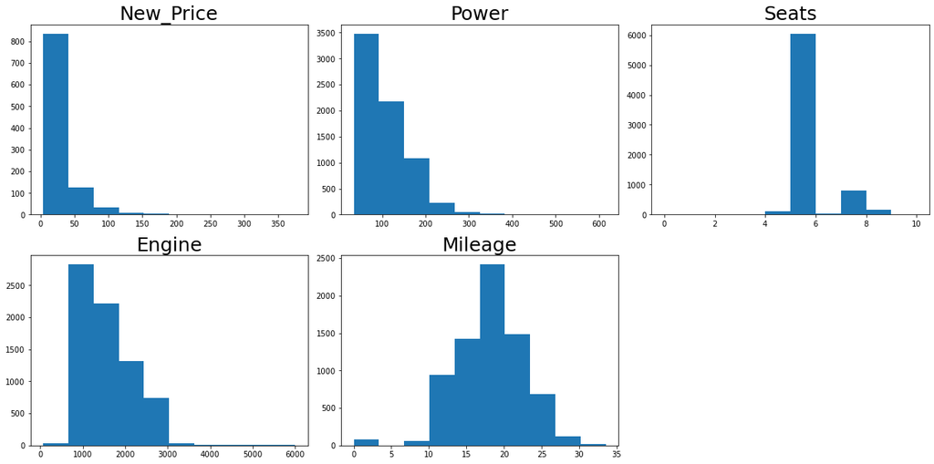

```python
# plotting histogram of all numerical variables
col = ["New_Price", "Power", "Seats", "Engine","Mileage"]
plt.figure(figsize=(17,75))

for i in range(len(col)):
    plt.subplot(18, 3, i+1)
    plt.hist(df[col[i]])
    plt.tight_layout()
    plt.title(col[i], fontsize=25)

plt.show()
```

```python
#descriptives before any changes
df.describe().T
```

|  | count | mean | std | min | 25% | 50% | 75% | max |
| --- | --- | --- | --- | --- | --- | --- | --- | --- |
| Year | 7253.000 | 2013.365 | 3.254 | 1996.000 | 2011.000 | 2014.000 | 2016.000 | 2019.000 |
| Kilometers_Driven | 7253.000 | 58699.063 | 84427.721 | 171.000 | 34000.000 | 53416.000 | 73000.000 | 6500000.000 |
| Mileage | 7251.000 | 18.142 | 4.562 | 0.000 | 15.170 | 18.160 | 21.100 | 33.540 |
| Engine | 7207.000 | 1616.573 | 595.285 | 72.000 | 1198.000 | 1493.000 | 1968.000 | 5998.000 |
| Power | 7078.000 | 112.765 | 53.494 | 34.200 | 75.000 | 94.000 | 138.100 | 616.000 |
| Seats | 7200.000 | 5.280 | 0.812 | 0.000 | 5.000 | 5.000 | 5.000 | 10.000 |
| New_Price | 1006.000 | 22.780 | 27.759 | 3.910 | 7.885 | 11.570 | 26.043 | 375.000 |
| Price | 6019.000 | 9.479 | 11.188 | 0.440 | 3.500 | 5.640 | 9.950 | 160.000 |

##### Observations

It looks like Mileage (The standard mileage offered by the car company in kmpl or km/kg) has some zero values which seem nonsensical as no car would have standard mileage equal to zero. Since the distribution of values in Mileage tends to normality we will substitute zeros (81 instances as seen in above section) for the mean

```python
df['Mileage'] = df['Mileage'].replace(0,df['Mileage'].mean())
```

```python
df['Mileage'].describe()
```

```
count   7251.000
mean      18.344
std        4.135
min        6.400
25%       15.400
50%       18.160
75%       21.100
max       33.540
Name: Mileage, dtype: float64
```

##### Observations

The mean and standard deviation of the distribution before and after changing Mileage values equal to zero for the mean are similar, indicating that the change did not alter the distribution in a biasing manner.

Mileage mean and standard deviation before change:

- mean 18.141580
- std 4.562197

Mileage descriptives after change:

- mean 18.344238
- std 4.134674

The distribution of the Mileage and Seats looks to be centered around the mean more so than New_Price, Engine, and Power which have right-skewed distributions. We will therefore substitude missing values for the mean for Mileage and Seats and for the median for New Price, Engine and Power.

```python
#using `fillna` with numeric columns Mileage and Seats to fill in missing values with the mean
mean_fillna = ['Mileage','Seats']
for colname in mean_fillna:
    print(df[colname].isnull().sum())
    df[colname].fillna(df[colname].mean(), inplace=True)
    print(df[colname].isnull().sum())
```

```
2
0
53
0
```

```python
#using `fillna` to fill in New Price, Engine, and Power with their median value
mean_fillna2 = ['New_Price','Engine', 'Power']
for colname in mean_fillna2:
    print(df[colname].isnull().sum())
    df[colname].fillna(df[colname].median(), inplace=True)
    print(df[colname].isnull().sum())
```

```
6247
0
46
0
175
0
```

Substitution for mean and median values successfully completed. Descriptives provided below.

```python
# Examining distribution after filling missing values
df.describe().T
```

|  | count | mean | std | min | 25% | 50% | 75% | max |
| --- | --- | --- | --- | --- | --- | --- | --- | --- |
| Year | 7253.000 | 2013.365 | 3.254 | 1996.000 | 2011.000 | 2014.000 | 2016.000 | 2019.000 |
| Kilometers_Driven | 7253.000 | 58699.063 | 84427.721 | 171.000 | 34000.000 | 53416.000 | 73000.000 | 6500000.000 |
| Mileage | 7253.000 | 18.344 | 4.134 | 6.400 | 15.400 | 18.160 | 21.100 | 33.540 |
| Engine | 7253.000 | 1615.790 | 593.475 | 72.000 | 1198.000 | 1493.000 | 1968.000 | 5998.000 |
| Power | 7253.000 | 112.312 | 52.923 | 34.200 | 77.000 | 94.000 | 138.030 | 616.000 |
| Seats | 7253.000 | 5.280 | 0.809 | 0.000 | 5.000 | 5.000 | 5.000 | 10.000 |
| New_Price | 7253.000 | 13.125 | 11.036 | 3.910 | 11.570 | 11.570 | 11.570 | 375.000 |
| Price | 6019.000 | 9.479 | 11.188 | 0.440 | 3.500 | 5.640 | 9.950 | 160.000 |

##### Observations

Change to New Price though, given the large number of missing values (6247), was drastic.

Mileage

- Mean, Std Dev (before): 18.142, 4.562
- Mean, Std Dev (after): 18.344238, 4.134104

Engine

- Mean, Std Dev (before): 1616.573, 595.285137
- Mean, Std Dev (after): 1615.790, 593.475

Power

- Mean, Std Dev (before): 112.765214, 53.493553
- Mean, Std Dev (after): 112.312, 52.923

Seats

- Mean, Std Dev (before): 5.280, 0.811660
- Mean, Std Dev (after): 5.280, 0.809

New Price

- Mean, Std Dev (before): 22.780, 27.759
- Mean, Std Dev (after): 13.125, 11.036

```python
df.isnull().sum().sort_values(ascending=False)
```

```
Price                1234
New_Price               0
Seats                   0
Power                   0
Engine                  0
Mileage                 0
Owner_Type              0
Transmission            0
Fuel_Type               0
Kilometers_Driven       0
Year                    0
Location                0
Name                    0
dtype: int64
```

We are still left with a large number of missing values in the target variable, *Price*

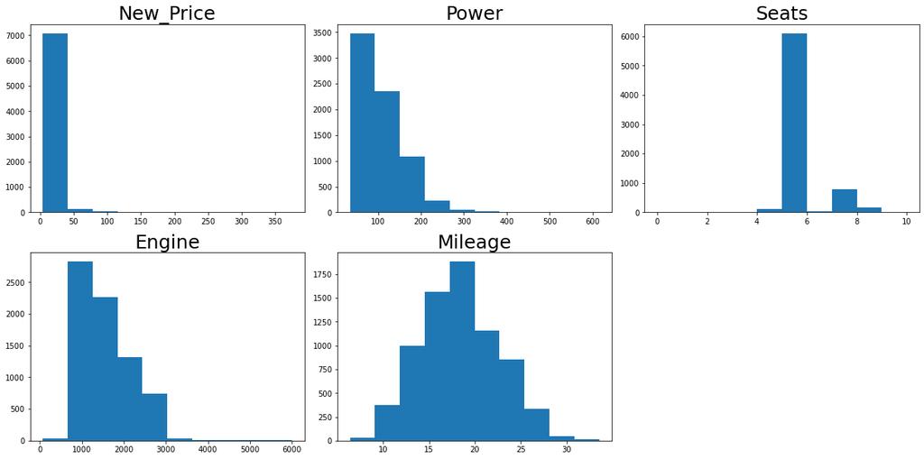

```python
# plotting histogram of all numerical variables
col = ["New_Price", "Power", "Seats", "Engine","Mileage"]
plt.figure(figsize=(17,75))

for i in range(len(col)):
    plt.subplot(18, 3, i+1)
    plt.hist(df[col[i]])
    plt.tight_layout()
    plt.title(col[i], fontsize=25)

plt.show()
```

##### Observations

As 6247 out of 7253 values for *New_Price* were imputed with the distribution's median, we observe a reduction/narrowing of the distribution around the median value.

#### Dropping missing values in the target variable

```python
#Dropping the remaining missing values which are now only left in the target variable, Price
df = df.dropna()
```

```python
df.isnull().sum().sort_values(ascending=False)
```

```
Price                0
New_Price            0
Seats                0
Power                0
Engine               0
Mileage              0
Owner_Type           0
Transmission         0
Fuel_Type            0
Kilometers_Driven    0
Year                 0
Location             0
Name                 0
dtype: int64
```

```python
df.info()
```

```
<class 'pandas.core.frame.DataFrame'>
Int64Index: 6019 entries, 0 to 6018
Data columns (total 13 columns):
 #   Column             Non-Null Count  Dtype
---  ------             --------------  -----
 0   Name               6019 non-null   object
 1   Location           6019 non-null   object
 2   Year               6019 non-null   int64
 3   Kilometers_Driven  6019 non-null   int64
 4   Fuel_Type          6019 non-null   object
 5   Transmission       6019 non-null   object
 6   Owner_Type         6019 non-null   object
 7   Mileage            6019 non-null   float64
 8   Engine             6019 non-null   float64
 9   Power              6019 non-null   float64
 10  Seats              6019 non-null   float64
 11  New_Price          6019 non-null   float64
 12  Price              6019 non-null   float64
dtypes: float64(6), int64(2), object(5)
memory usage: 658.3+ KB
```

After dropping na values for price new total rows for the dataset: 6019

### Extracting car brand from 'Name' column

We know that brands play a role in determining car prices. Let's pull that valuable information from the data

```python
# function below takes a string, splits it, and returns the first word
def take_first(name):
    if isinstance(name, str):
        splt = name.split(" ")
        return str(splt[0])

df['Brand'] = df['Name'].apply(take_first)
```

```python
#We notice different "Isuzu" written in all caps thereby being read by Python
#as a different brand name. Let's change so that only one brand stands as Isuzu
df["Brand"].replace({"ISUZU": "Isuzu"}, inplace=True)
```

```python
#Let's take a look at the frequency of observations for each brand
df["Brand"].value_counts(normalize=True)
```

```
Maruti          0.201
Hyundai         0.184
Honda           0.101
Toyota          0.068
Mercedes-Benz   0.053
Volkswagen      0.052
Ford            0.050
Mahindra        0.045
BMW             0.044
Audi            0.039
Tata            0.031
Skoda           0.029
Renault         0.024
Chevrolet       0.020
Nissan          0.015
Land            0.010
Jaguar          0.007
Fiat            0.005
Mitsubishi      0.004
Mini            0.004
Volvo           0.003
Porsche         0.003
Jeep            0.002
Datsun          0.002
Isuzu           0.000
Force           0.000
Lamborghini     0.000
Bentley         0.000
Ambassador      0.000
Smart           0.000
Name: Brand, dtype: float64
```

```python
#Number of unique brand values
df.Brand.nunique()
```

```
30
```

##### Observations

```python
#Let's divide brands into country/region of origin categories
#(european category further divided into popular and luxury - since luxury brands make such a big portion of this group)

brand_cats = []

for brand in df["Brand"]:
    if brand == 'Maruti' or brand == 'Tata' or brand == 'Mahindra' or brand == 'Ambassador' or brand == 'Force':
        brand_cats.append("Indian")
    elif brand == 'Ford' or brand == 'Chevrolet' or brand == 'Jeep':
        brand_cats.append("American")
    elif brand == 'Hyundai' or brand == 'Honda' or brand == 'Nissan' or brand == 'Toyota' or brand == 'Mitsubishi' or brand == 'Datsun'or brand == 'Isuzu':
        brand_cats.append("Japanese-Korean")
    elif brand == 'Volkswagen' or brand == 'Renault' or brand == 'Skoda' or brand == 'Fiat' or brand == 'Smart':
        brand_cats.append("European_popular")
    else:
        brand_cats.append("European_luxury")

df["Brand_cats"] = brand_cats
```

```python
df["Brand_cats"].value_counts()
```

```
Japanese-Korean     2260
Indian              1673
European_luxury      988
European_popular     662
American             436
Name: Brand_cats, dtype: int64
```

```python
jp_k = df[(df["Brand_cats"] == "Japanese-Korean")]
indian = df[(df["Brand_cats"] == "Indian")]
euro_lux = df[(df["Brand_cats"] == "European_luxury")]
euro_pop = df[(df["Brand_cats"] == "European_popular")]
american = df[(df["Brand_cats"] == "American")]
```

Examining price distributions by brand origin:

```python
jp_k.groupby("Brand")["Price"].describe()
```

| Brand | count | mean | std | min | 25% | 50% | 75% | max |
| --- | --- | --- | --- | --- | --- | --- | --- | --- |
| Datsun | 13.000 | 3.049 | 0.476 | 2.250 | 2.700 | 3.100 | 3.310 | 3.950 |
| Honda | 608.000 | 5.412 | 2.541 | 0.900 | 3.540 | 4.950 | 6.585 | 17.500 |
| Hyundai | 1107.000 | 5.343 | 3.311 | 0.450 | 3.095 | 4.600 | 6.450 | 23.000 |
| Isuzu | 3.000 | 14.697 | 6.120 | 8.000 | 12.045 | 16.090 | 18.045 | 20.000 |
| Mitsubishi | 27.000 | 11.059 | 7.139 | 1.000 | 5.865 | 9.950 | 13.725 | 28.000 |
| Nissan | 91.000 | 4.738 | 1.759 | 1.750 | 3.275 | 4.300 | 6.100 | 8.920 |
| Toyota | 411.000 | 11.580 | 7.002 | 1.500 | 5.550 | 10.750 | 16.500 | 35.820 |

```python
indian.groupby("Brand")["Price"].describe()
```

| Brand | count | mean | std | min | 25% | 50% | 75% | max |
| --- | --- | --- | --- | --- | --- | --- | --- | --- |
| Ambassador | 1.000 | 1.350 | nan | 1.350 | 1.350 | 1.350 | 1.350 | 1.350 |
| Force | 3.000 | 9.333 | 2.309 | 8.000 | 8.000 | 8.000 | 10.000 | 12.000 |
| Mahindra | 272.000 | 8.046 | 3.599 | 1.500 | 5.500 | 7.570 | 10.082 | 17.630 |
| Maruti | 1211.000 | 4.517 | 2.296 | 0.450 | 2.800 | 4.150 | 5.995 | 11.500 |
| Tata | 186.000 | 3.563 | 2.694 | 0.440 | 1.695 | 2.900 | 4.580 | 17.850 |

```python
euro_lux.groupby("Brand")["Price"].describe()
```

| Brand | count | mean | std | min | 25% | 50% | 75% | max |
| --- | --- | --- | --- | --- | --- | --- | --- | --- |
| Audi | 236.000 | 25.538 | 12.345 | 7.500 | 17.500 | 23.500 | 31.947 | 72.940 |
| BMW | 267.000 | 25.243 | 15.165 | 6.300 | 13.925 | 21.000 | 32.160 | 93.670 |
| Bentley | 1.000 | 59.000 | nan | 59.000 | 59.000 | 59.000 | 59.000 | 59.000 |
| Jaguar | 40.000 | 37.632 | 18.155 | 16.000 | 26.515 | 31.900 | 41.000 | 100.000 |
| Lamborghini | 1.000 | 120.000 | nan | 120.000 | 120.000 | 120.000 | 120.000 | 120.000 |
| Land | 60.000 | 39.260 | 24.146 | 11.000 | 21.527 | 35.000 | 47.365 | 160.000 |
| Mercedes-Benz | 318.000 | 26.810 | 15.892 | 3.900 | 14.500 | 24.000 | 35.000 | 90.000 |
| Mini | 26.000 | 26.897 | 6.169 | 17.000 | 22.000 | 24.285 | 31.887 | 39.750 |
| Porsche | 18.000 | 48.348 | 19.633 | 2.020 | 40.727 | 47.020 | 63.237 | 75.000 |
| Volvo | 21.000 | 18.803 | 5.854 | 7.250 | 16.000 | 18.250 | 23.580 | 32.500 |

```python
euro_pop.groupby("Brand")["Price"].describe()
```

| Brand | count | mean | std | min | 25% | 50% | 75% | max |
| --- | --- | --- | --- | --- | --- | --- | --- | --- |
| Fiat | 28.000 | 3.269 | 1.901 | 0.550 | 2.088 | 2.600 | 4.700 | 7.710 |
| Renault | 145.000 | 5.799 | 2.385 | 2.400 | 3.800 | 5.490 | 7.100 | 14.010 |
| Skoda | 173.000 | 7.559 | 5.037 | 1.250 | 4.250 | 6.000 | 9.720 | 27.300 |
| Smart | 1.000 | 3.000 | nan | 3.000 | 3.000 | 3.000 | 3.000 | 3.000 |
| Volkswagen | 315.000 | 5.307 | 2.461 | 2.100 | 3.750 | 4.890 | 6.155 | 24.900 |

```python
american.groupby("Brand")["Price"].describe()
```

| Brand | count | mean | std | min | 25% | 50% | 75% | max |
| --- | --- | --- | --- | --- | --- | --- | --- | --- |
| Chevrolet | 121.000 | 3.044 | 1.828 | 0.750 | 1.750 | 2.500 | 3.700 | 9.870 |
| Ford | 300.000 | 6.889 | 7.509 | 0.690 | 2.750 | 5.345 | 7.342 | 56.800 |
| Jeep | 15.000 | 18.719 | 2.159 | 15.000 | 17.475 | 18.500 | 19.730 | 23.910 |

We examined brand origin and price levels to determine the best matches for brands with low frequency observations. Replacement for low frequency brands as follows

- Lamborghini' replaced as 'Land Rover'
- 'Bentley': 'Jaguar'
- 'Smart': 'Fiat'
- 'Ambassador': 'Tata'
- 'Mitsubishi': 'Toyota'
- 'Isuzu': 'Toyota'
- 'Datsun':'Nissan'
- 'Volvo': 'BMW'
- 'Porsche': 'Jaguar'
- 'Mini': 'Audi'
- 'Jeep': 'BMW'
- 'Force': 'Mahindra'

```python
df["Brand"].replace({'Lamborghini': 'Land',
                     'Bentley': 'Jaguar',
                     'Smart': 'Fiat',
                     'Ambassador': 'Tata',
                    'Mitsubishi': 'Toyota',
                    'Isuzu': 'Toyota',
                    'Datsun':'Nissan',
                    'Volvo': 'BMW',
                    'Porsche': 'Jaguar',
                    'Mini': 'Audi',
                    'Jeep': 'BMW',
                    'Force': 'Mahindra'}, inplace=True)
```

```python
#After replacement we end up with this number of unique brands in the dataset
df.Brand.nunique()
```

```
18
```

After replacement we end up with 18 unique brand values

```python
#dropping added column
df.drop("Brand_cats", axis=1, inplace=True)
```

```python
#dropping added dataframes
del jp_k
del indian
del euro_lux
del euro_pop
del american
```

### Making categoricals into categorical types

```python
cat_cols = ['Name', 'Location', 'Fuel_Type',
            'Transmission', 'Owner_Type', 'Brand']

for colname in cat_cols:
    df[colname] = df[colname].astype('category')

df.info()
```

```
<class 'pandas.core.frame.DataFrame'>
Int64Index: 6019 entries, 0 to 6018
Data columns (total 14 columns):
 #   Column             Non-Null Count  Dtype
---  ------             --------------  -----
 0   Name               6019 non-null   category
 1   Location           6019 non-null   category
 2   Year               6019 non-null   int64
 3   Kilometers_Driven  6019 non-null   int64
 4   Fuel_Type          6019 non-null   category
 5   Transmission       6019 non-null   category
 6   Owner_Type         6019 non-null   category
 7   Mileage            6019 non-null   float64
 8   Engine             6019 non-null   float64
 9   Power              6019 non-null   float64
 10  Seats              6019 non-null   float64
 11  New_Price          6019 non-null   float64
 12  Price              6019 non-null   float64
 13  Brand              6019 non-null   category
dtypes: category(6), float64(6), int64(2)
memory usage: 560.7 KB
```

### Basic Summary Statitics

```python
pd.set_option(
    "display.float_format", lambda x: "%.3f" % x
)  # to display numbers in digits
df.describe(include="all").T  # quick summary of numeric features
```

|  | count | unique | top | freq | mean | std | min | 25% | 50% | 75% | max |
| --- | --- | --- | --- | --- | --- | --- | --- | --- | --- | --- | --- |
| Name | 6019 | 1876 | Mahindra XUV500 W8 2WD | 49 | NaN | NaN | NaN | NaN | NaN | NaN | NaN |
| Location | 6019 | 11 | Mumbai | 790 | NaN | NaN | NaN | NaN | NaN | NaN | NaN |
| Year | 6019.000 | NaN | NaN | NaN | 2013.358 | 3.270 | 1998.000 | 2011.000 | 2014.000 | 2016.000 | 2019.000 |
| Kilometers_Driven | 6019.000 | NaN | NaN | NaN | 58738.380 | 91268.843 | 171.000 | 34000.000 | 53000.000 | 73000.000 | 6500000.000 |
| Fuel_Type | 6019 | 5 | Diesel | 3205 | NaN | NaN | NaN | NaN | NaN | NaN | NaN |
| Transmission | 6019 | 2 | Manual | 4299 | NaN | NaN | NaN | NaN | NaN | NaN | NaN |
| Owner_Type | 6019 | 4 | First | 4929 | NaN | NaN | NaN | NaN | NaN | NaN | NaN |
| Mileage | 6019.000 | NaN | NaN | NaN | 18.340 | 4.151 | 6.400 | 15.400 | 18.160 | 21.100 | 33.540 |
| Engine | 6019.000 | NaN | NaN | NaN | 1620.509 | 599.635 | 72.000 | 1198.000 | 1493.000 | 1969.000 | 5998.000 |
| Power | 6019.000 | NaN | NaN | NaN | 112.796 | 53.312 | 34.200 | 78.000 | 94.000 | 138.030 | 560.000 |
| Seats | 6019.000 | NaN | NaN | NaN | 5.279 | 0.806 | 0.000 | 5.000 | 5.000 | 5.000 | 10.000 |
| New_Price | 6019.000 | NaN | NaN | NaN | 13.145 | 10.459 | 3.910 | 11.570 | 11.570 | 11.570 | 230.000 |
| Price | 6019.000 | NaN | NaN | NaN | 9.479 | 11.188 | 0.440 | 3.500 | 5.640 | 9.950 | 160.000 |
| Brand | 6019 | 18 | Maruti | 1211 | NaN | NaN | NaN | NaN | NaN | NaN | NaN |

```python
# looking at value counts for non-numeric features

num_to_display = 15  # defining up to how many values to display
for colname in df.dtypes[df.dtypes == 'category'].index:
    val_counts = df[colname].value_counts(dropna=False)  # "dropna=False" to see NA counts
    print(val_counts[:num_to_display])
    if len(val_counts) > num_to_display:
        print(f'Only displaying first {num_to_display} of {len(val_counts)} values.')
    print('\n\n') # just for more space between
```

```
Mahindra XUV500 W8 2WD        49
Maruti Swift VDI              45
Honda City 1.5 S MT           34
Maruti Swift Dzire VDI        34
Maruti Swift VDI BSIV         31
Maruti Ritz VDi               30
Hyundai i10 Sportz            30
Toyota Fortuner 3.0 Diesel    29
Honda Amaze S i-Dtech         27
Hyundai Grand i10 Sportz      27
Maruti Ertiga VDI             25
Honda Brio S MT               25
Honda City 1.5 V MT           24
Maruti Wagon R VXI            23
Hyundai Verna 1.6 SX          23
Name: Name, dtype: int64
Only displaying first 15 of 1876 values.



Mumbai        790
Hyderabad     742
Kochi         651
Coimbatore    636
Pune          622
Delhi         554
Kolkata       535
Chennai       494
Jaipur        413
Bangalore     358
Ahmedabad     224
Name: Location, dtype: int64



Diesel      3205
Petrol      2746
CNG           56
LPG           10
Electric       2
```

[output cut: 20 more lines]

```
Honda             608
Toyota            441
Mercedes-Benz     318
Volkswagen        315
BMW               303
Ford              300
Mahindra          275
Audi              262
Tata              187
Skoda             173
Renault           145
Chevrolet         121
Nissan            104
Name: Brand, dtype: int64
Only displaying first 15 of 18 values.
```

### Exploring Numeric Variables through Univariate Analysis

```python
# Function below helps to create a boxplot and histogram for any input numerical
# variable. It takes the numerical column as the input and returns the boxplots
# and histograms for the variable.

def histogram_boxplot(feature, figsize=(15,10), bins = None):
    """ Boxplot and histogram combined
    feature: 1-d feature array
    figsize: size of fig (default (9,8))
    bins: number of bins (default None / auto)
    """
    f2, (ax_box2, ax_hist2) = plt.subplots(nrows = 2, # Number of rows of the subplot grid= 2
                                           sharex = True, # x-axis will be shared among all subplots
                                           gridspec_kw = {"height_ratios": (.25, .75)},
                                           figsize = figsize
                                           ) # creating the 2 subplots
    sns.boxplot(feature, ax=ax_box2, showmeans=True, color='green') # boxplot will be created and a star will indicate the mean value of the column
    sns.distplot(feature, kde=F, ax=ax_hist2, bins=bins) if bins else sns.distplot(feature, kde=False, ax=ax_hist2) # For histogram
    ax_hist2.axvline(np.mean(feature), color='g', linestyle='--') # Add mean to the histogram
    ax_hist2.axvline(np.median(feature), color='black', linestyle='-') # Add median to the histogram
```

### Examining need for data transformations of numeric variables

#### Kilometers Driven

```python
df['Kilometers_Driven'].describe()
```

```
count      6019.000
mean      58738.380
std       91268.843
min         171.000
25%       34000.000
50%       53000.000
75%       73000.000
max     6500000.000
Name: Kilometers_Driven, dtype: float64
```

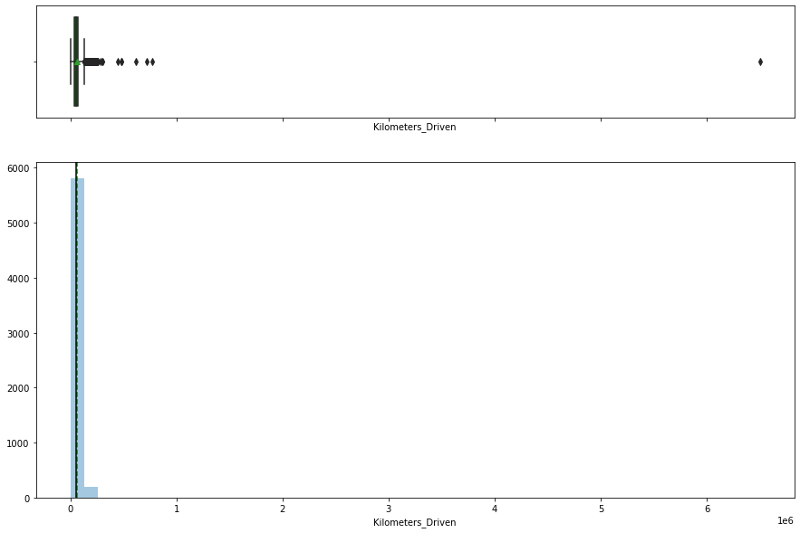

```python
histogram_boxplot(df['Kilometers_Driven'])
```

##### Observations

'Kilometers_Driven' feature looks to be highly skewed. To handle the skewness and help data behave more like a normal distribution, we will look at different transformations: square root, log and arcsinh log

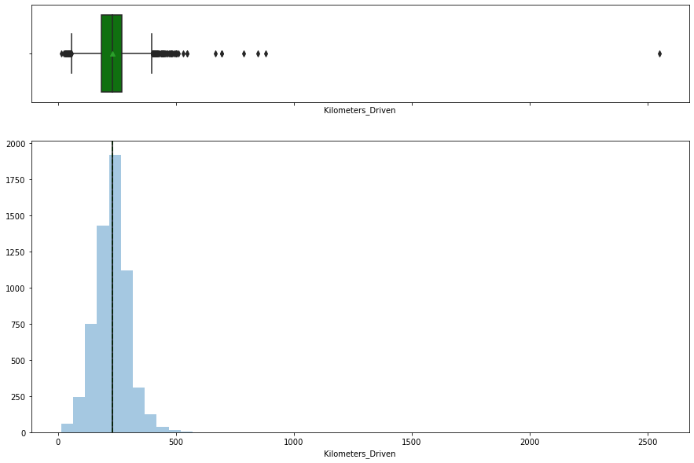

```python
# looking at data distribution when transformed by taking the square root of Kilometers Driven values
histogram_boxplot(np.sqrt(df['Kilometers_Driven']))
```

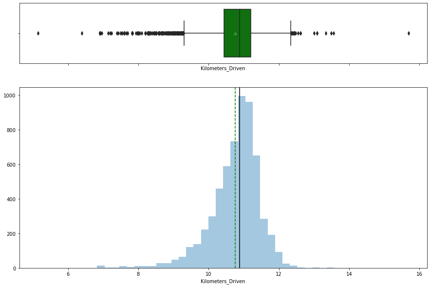

```python
# looking at data distribution when transformed by taking the log of Kilometers Driven values
histogram_boxplot(np.log(df['Kilometers_Driven']))
```

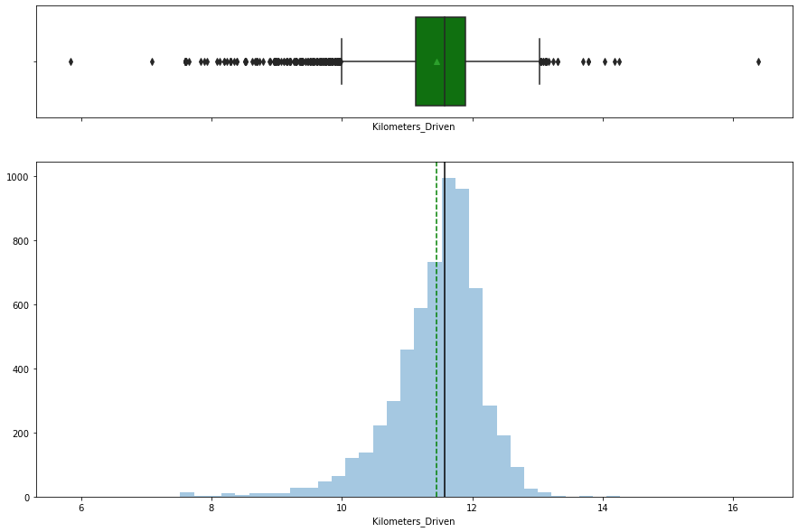

```python
# looking at data distribution when transformed by taking the arcsinh log of Kilometers Driven values
histogram_boxplot(np.arcsinh(df['Kilometers_Driven']))
```

##### Observations

All three transformations have helped handle skewness in the data pertaining to Kilometers Driven, however, square root looked as best toward getting data distribution closest to normality - mean and median more closely alligned than in the log and arcsinh log distributions.

```python
df['Kilometers_Driven' + '_sqrt'] = np.sqrt(df['Kilometers_Driven'])
df.drop(['Kilometers_Driven'], axis=1, inplace=True)
```

```
count   6019.000
mean     229.604
std       77.598
min       13.077
25%      184.391
50%      230.217
75%      270.185
max     2549.510
Name: Kilometers_Driven_sqrt, dtype: float64
```

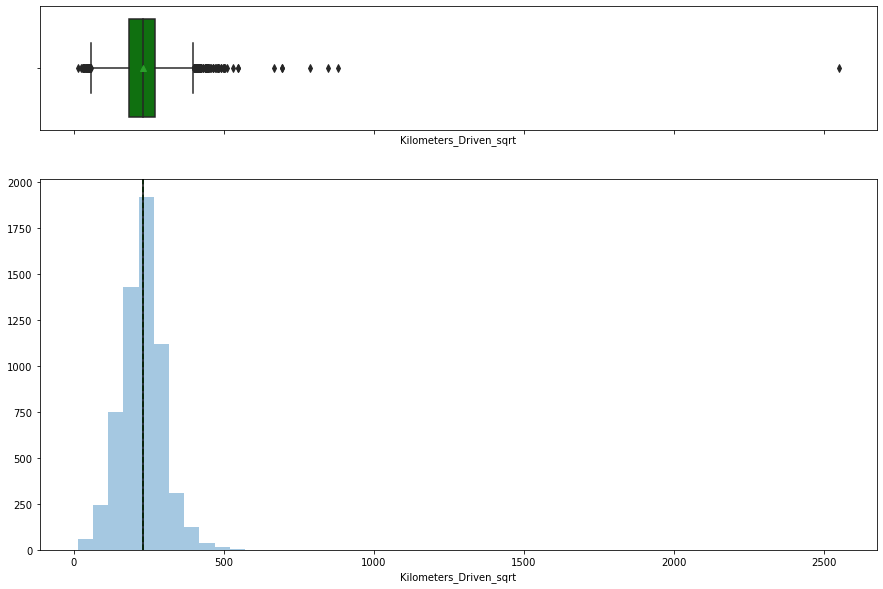

```python
print(df['Kilometers_Driven_sqrt'].describe())
histogram_boxplot(df['Kilometers_Driven_sqrt'])
```

##### Observations

Although we still see the presence of outliers but the distribution alligns much more closely to normality after the transformation.

#### Mileage

```python
df['Mileage'].describe()
```

```
count   6019.000
mean      18.340
std        4.151
min        6.400
25%       15.400
50%       18.160
75%       21.100
max       33.540
Name: Mileage, dtype: float64
```

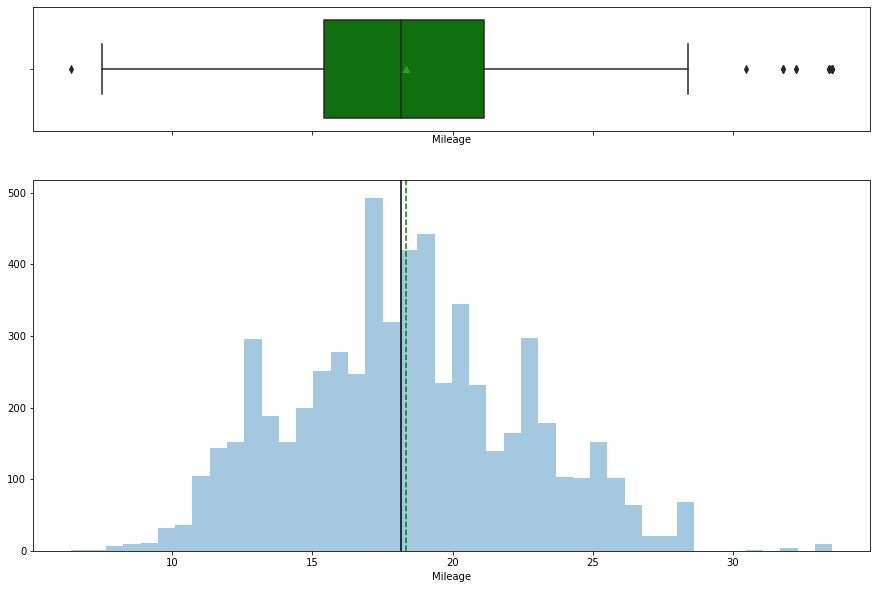

```python
# Visually examining the distribution of values in mileage
histogram_boxplot(df['Mileage'])
```

##### Observations

Mileage looks to be close to normally distributed. No transformations to handle skewness needed.

#### Engine

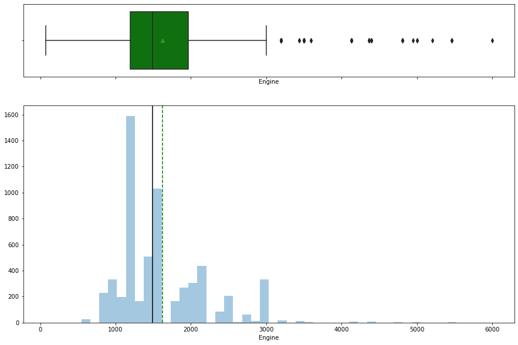

```python
histogram_boxplot(df['Engine'])
```

```python
df['Engine'].describe()
```

```
count   6019.000
mean    1620.509
std      599.635
min       72.000
25%     1198.000
50%     1493.000
75%     1969.000
max     5998.000
Name: Engine, dtype: float64
```

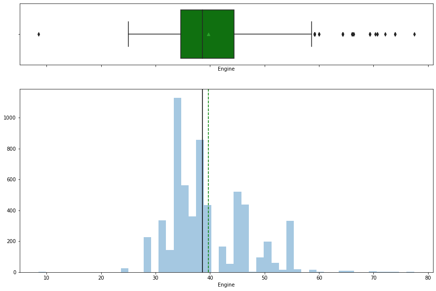

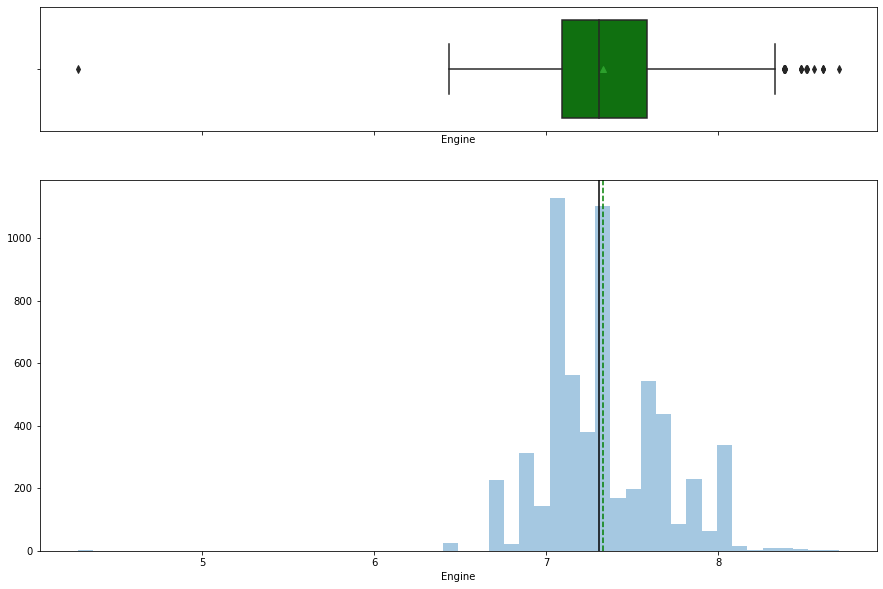

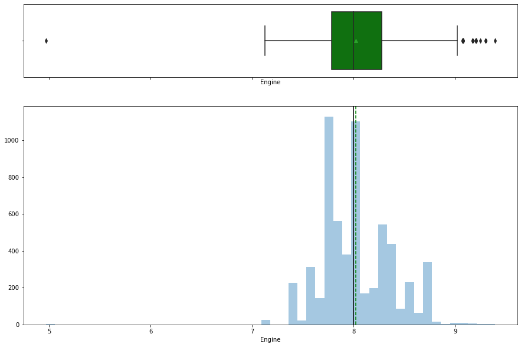

```python
histogram_boxplot(np.sqrt(df['Engine']))
histogram_boxplot(np.log(df['Engine']))
histogram_boxplot(np.arcsinh(df['Engine']))
```

##### Observations

We see that log and arcsinh log transformations handle skewness in *Engine* very similarly. We will opt to transform each x in Engine by log of x since it is the simpler of the two transformations.

```python
df['Engine' + '_log'] = np.log(df['Engine'])
df.drop(['Engine'], axis=1, inplace=True)
```

```
count   6019.000
mean       7.331
std        0.339
min        4.277
25%        7.088
50%        7.309
75%        7.585
max        8.699
Name: Engine_log, dtype: float64
```

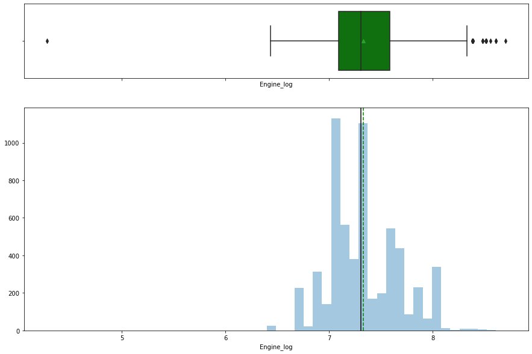

```python
print(df['Engine_log'].describe())
histogram_boxplot(df['Engine_log'])
```

#### Power

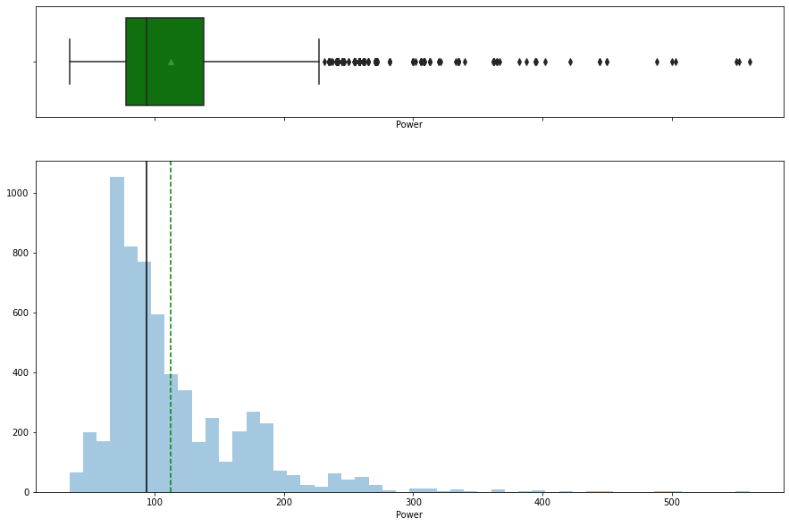

```python
histogram_boxplot(df['Power'])
```

```python
df['Power'].describe()
```

```
count   6019.000
mean     112.796
std       53.312
min       34.200
25%       78.000
50%       94.000
75%      138.030
max      560.000
Name: Power, dtype: float64
```

##### Observations

We see the *Power* distribution as right-skewed, with the presence of large value outliers. To help handle the skeweness and reduce the scale of the data distribution we will examine the impact of square root, log and arcsinh log transformations below

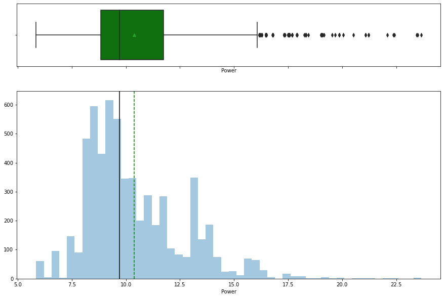

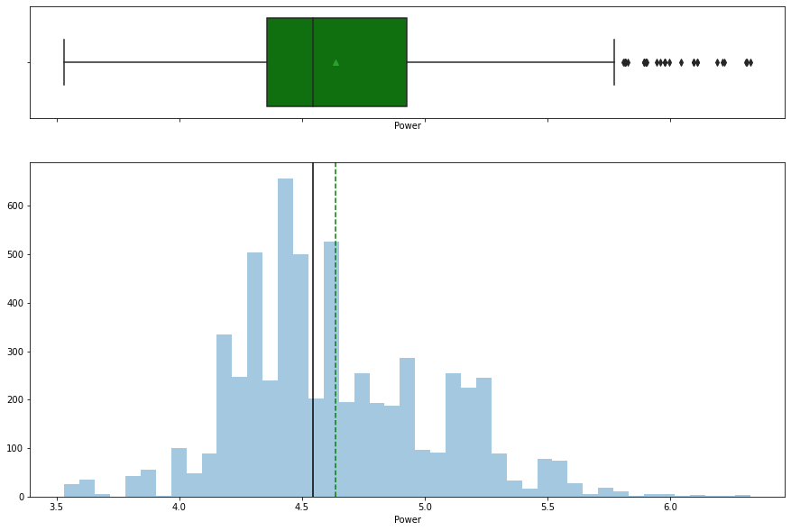

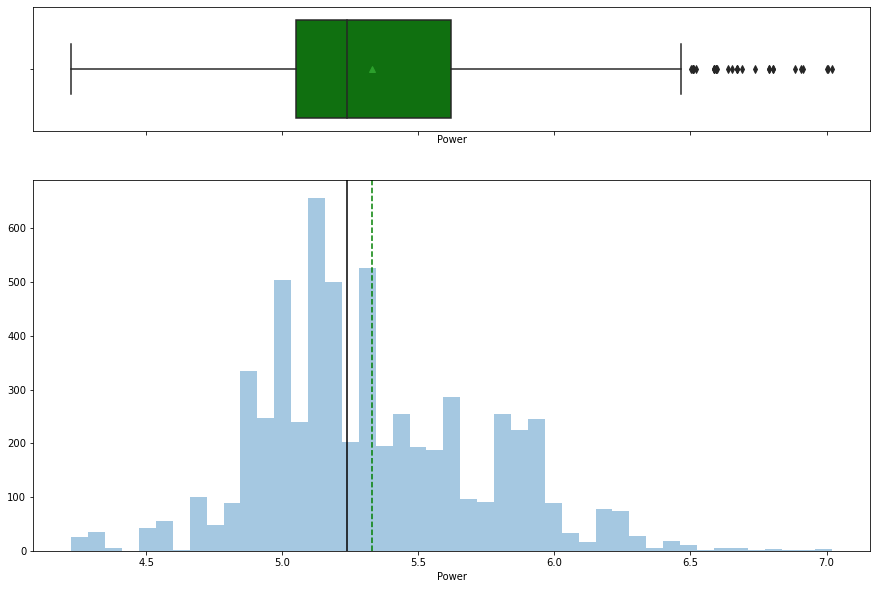

```python
histogram_boxplot(np.sqrt(df['Power']))
histogram_boxplot(np.log(df['Power']))
histogram_boxplot(np.arcsinh(df['Power']))
```

##### Observations

We see that log and arcsinh log transformations handle skewness in *Power* very similarly. We will opt to transform each x in Power by log of x since it is the simpler of the two transformations.

```python
df['Power' + '_log'] = np.log(df['Power'])
df.drop(['Power'], axis=1, inplace=True)
```

```python
print(df['Power_log'].describe())
```

```
count   6019.000
mean       4.635
std        0.412
min        3.532
25%        4.357
50%        4.543
75%        4.927
max        6.328
Name: Power_log, dtype: float64
```

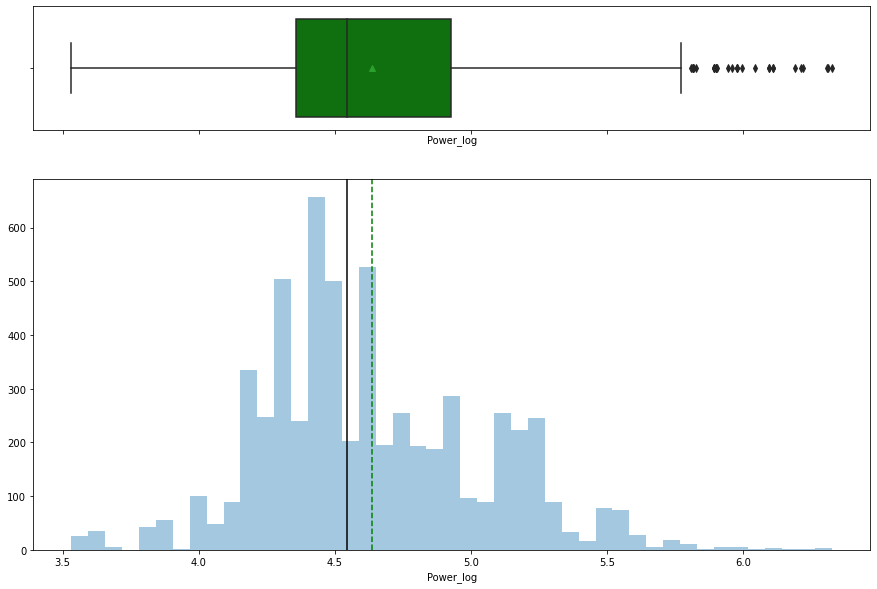

```python
histogram_boxplot(df['Power_log'])
```

#### Seats

```python
df.Seats.describe()
```

```
count   6019.000
mean       5.279
std        0.806
min        0.000
25%        5.000
50%        5.000
75%        5.000
max       10.000
Name: Seats, dtype: float64
```

```python
df.Seats.value_counts()
```

```
5.000     5014
7.000      674
8.000      134
4.000       99
5.280       42
6.000       31
2.000       16
10.000       5
9.000        3
0.000        1
Name: Seats, dtype: int64
```

##### Observations

The value zero for Seats seems nonsensical, we will treat it as a missing value and replace it with the mean value 5.280

```python
df['Seats'] = df['Seats'].replace(0,df['Seats'].mean())
```

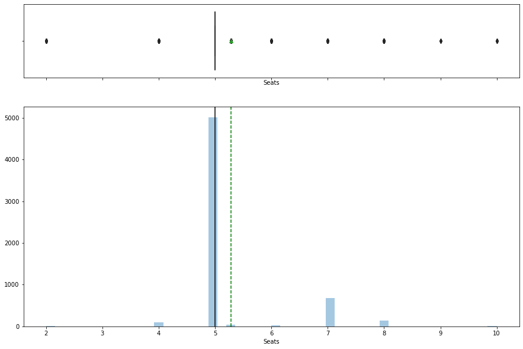

```python
histogram_boxplot(df['Seats'])
```

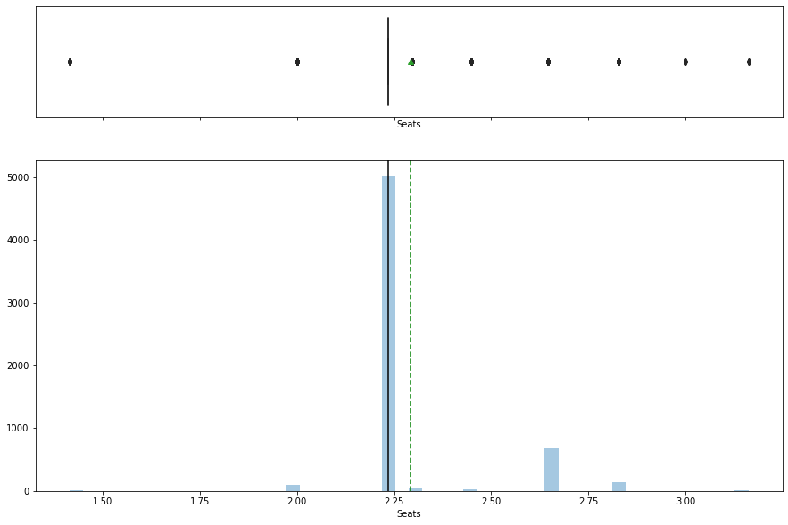

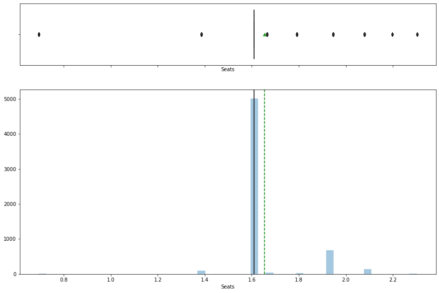

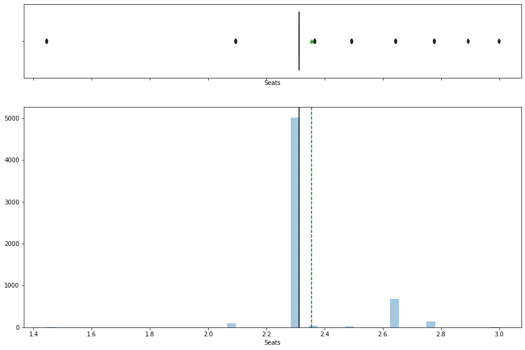

```python
histogram_boxplot(np.sqrt(df['Seats']))
histogram_boxplot(np.log(df['Seats']))
histogram_boxplot(np.arcsinh(df['Seats']))
```

##### Observations

Transformations did not work to reshape the distribution so we opt to leave Seats feature unaltered.

#### New_Price

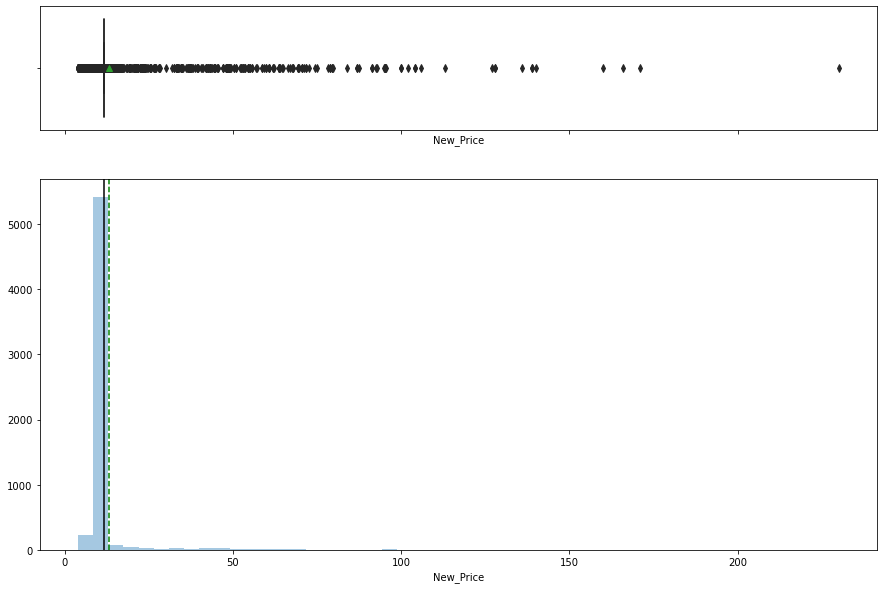

```python
histogram_boxplot(df['New_Price'])
```

```python
df['New_Price'].describe()
```

```
count   6019.000
mean      13.145
std       10.459
min        3.910
25%       11.570
50%       11.570
75%       11.570
max      230.000
Name: New_Price, dtype: float64
```

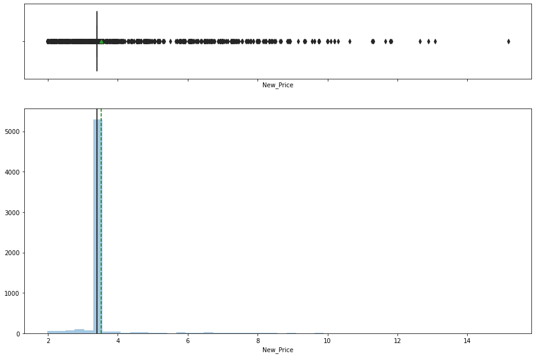

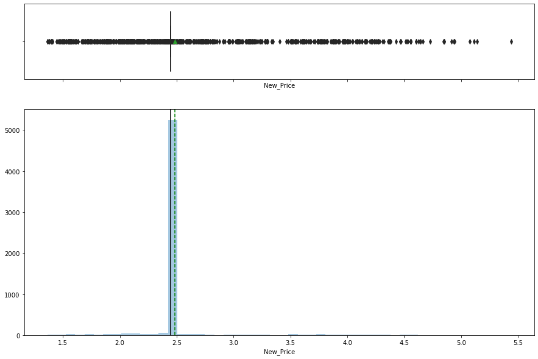

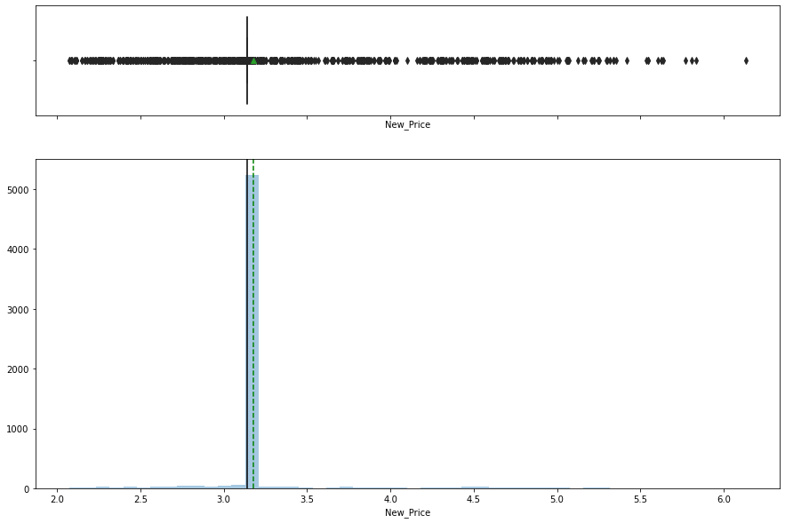

```python
histogram_boxplot(np.sqrt(df['New_Price']))
histogram_boxplot(np.log(df['New_Price']))
histogram_boxplot(np.arcsinh(df['New_Price']))
```

##### Observations

Given the narrowness of the New_Price data distribution (remembering that most values were imputed with the median to handle missing data) we will opt not to handle the feature with transformations.

### Examining Numerical Variables through Histograms

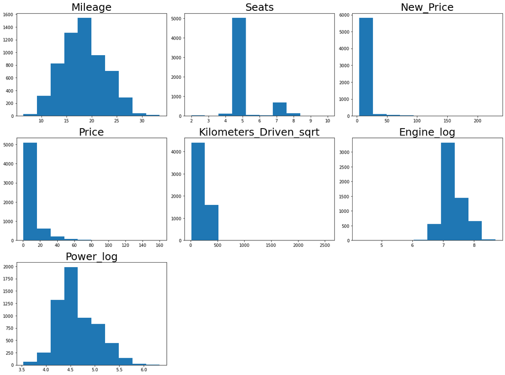

```python
# plotting histogram of all numerical variables


all_col = df.select_dtypes(include=np.number).columns.tolist()
all_col.remove("Year")
plt.figure(figsize=(17,75))

for i in range(len(all_col)):
    plt.subplot(18, 3, i+1)
    plt.hist(df[all_col[i]])
    plt.tight_layout()
    plt.title(all_col[i], fontsize=25)

plt.show()
```

#### Observations

- Mileage looks to be normally distributed
- Seats, New_Price, Price, Kilometers Driven look to be right skewed
- The log transformations of Engine and Power managed to make these distributions more normally distributed

## Outlier Treatment for Continuous Variables

Any value that is smaller than Q1 - 1.5IQR and greater than Q3 + 1.5IQR is defined as an outlier. We will treat outliers in the dataset by flooring and capping.

- All the values smaller than Q1 - 1.5IQR will be assigned the value equal to Q1 - 1.5IQR (flooring)
- All the values greater than Q3 + 1.5IQR will be assigned the value equal to Q3 + 1.5IQR (capping)

```python
# Let's treat outliers by flooring and capping
def treat_outliers(df, col):
    """
    treats outliers in a variable
    col: str, name of the numerical variable
    df: dataframe
    col: name of the column
    """
    Q1 = df[col].quantile(0.25)  # 25th quantile
    Q3 = df[col].quantile(0.75)  # 75th quantile
    IQR = Q3 - Q1
    Lower_Whisker = Q1 - 1.5 * IQR
    Upper_Whisker = Q3 + 1.5 * IQR

    # all the values smaller than Lower_Whisker will be assigned the value of Lower_Whisker
    # all the values greater than Upper_Whisker will be assigned the value of Upper_Whisker
    df[col] = np.clip(df[col], Lower_Whisker, Upper_Whisker)

    return df


def treat_outliers_all(df, col_list):
    """
    treat outlier in all numerical variables
    col_list: list of numerical variables
    df: data frame
    """
    for c in col_list:
        df = treat_outliers(df, c)

    return df
```

### Treating the outliers

```python
numerical_col = df.select_dtypes(include=np.number).columns.tolist()
numerical_col.remove("Year")
df = treat_outliers_all(df, numerical_col)
```

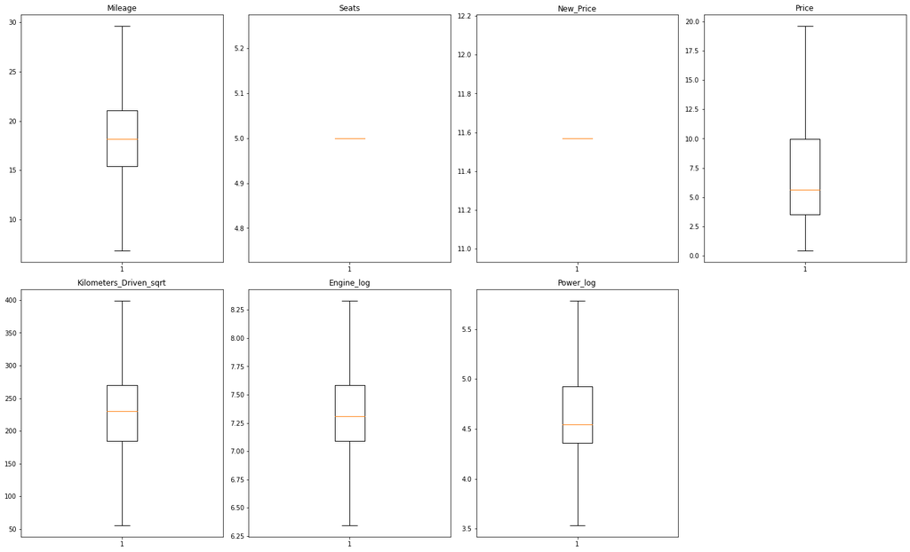

```python
# let's look at box plot to see if outliers have been treated or not
plt.figure(figsize=(20, 30))

for i, variable in enumerate(numerical_col):
    plt.subplot(5, 4, i + 1)
    plt.boxplot(df[variable], whis=1.5)
    plt.tight_layout()
    plt.title(variable)

plt.show()
```

```python
print("Value counts for Seats variable:","\n", df["Seats"].value_counts())
print("\n")
print("Descriptives for Seats variable:","\n", df["Seats"].describe())
```

```
Value counts for Seats variable:
 5.000    6019
Name: Seats, dtype: int64


Descriptives for Seats variable:
 count   6019.000
mean       5.000
std        0.000
min        5.000
25%        5.000
50%        5.000
75%        5.000
max        5.000
Name: Seats, dtype: float64
```

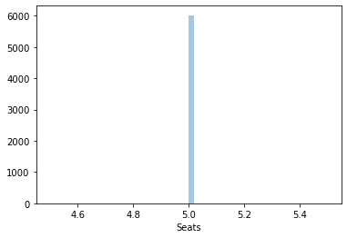

```python
sns.distplot(df["Seats"], kde=False);
```

```python
print("Value counts for New_Price variable:","\n", df["New_Price"].value_counts())
print("\n")
print("Descriptives for New_Price variable:","\n", df["New_Price"].describe())
```

```
Value counts for New_Price variable:
 11.570    6019
Name: New_Price, dtype: int64


Descriptives for New_Price variable:
 count   6019.000
mean      11.570
std        0.000
min       11.570
25%       11.570
50%       11.570
75%       11.570
max       11.570
Name: New_Price, dtype: float64
```

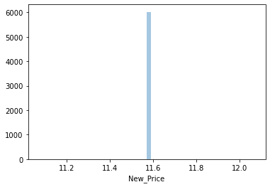

```python
sns.distplot(df["New_Price"], kde=False);
```

##### Observations

After treatment for missing values and outliers, the features *Seats* and *New_Price* ended up with very narrow distributions which render these inadequate for predictions. They will therefore be excluded from the model.

- Seats: out of 6019 possible values, 83% have 5 as number of seats.
- New_Price: out of 6019 possible values, 86% have price as 11.570.

### Looking at Correlations

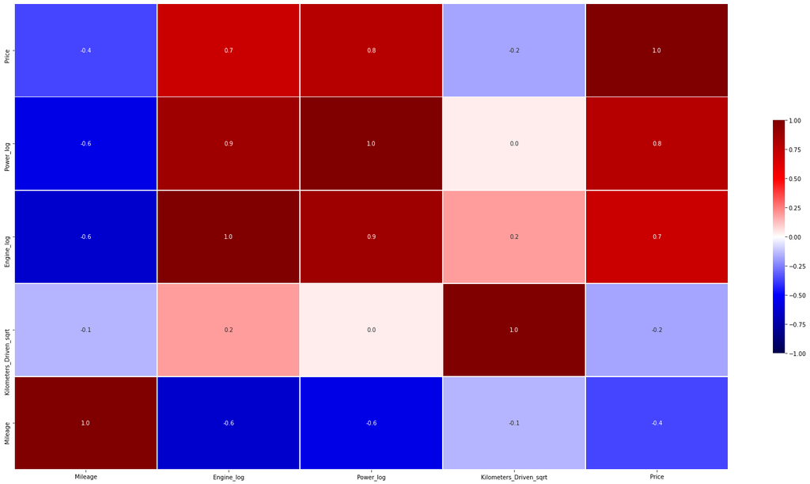

```python
col = ["Mileage", "Engine_log", "Power_log", "Kilometers_Driven_sqrt", "Price"]
corr = df[col].corr().sort_values(by=['Price'], ascending=False)

f, ax = plt.subplots(figsize=(28,15))

sns.heatmap(corr, cmap='seismic', annot=True, fmt=".1f", vmin=-1,vmax=1,center=0,square=False, linewidth=0.7, cbar_kws={"shrink": 0.5},)
```

#### Observations

- The highest correlations with Price observed were for Engine (0.7) and Power (0.8) - both correlated positively with Price
- We observe negative correlations between Price and Mileage and Price and Kilometers Driven
- Strong correlation present between Power and Engine: 0.9

### Examining Bivariate Relationships through Scatterplots

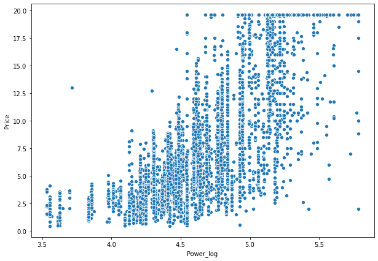

```python
plt.figure(figsize=(10,7))
sns.scatterplot(y="Price", x="Power_log", data=df);
```

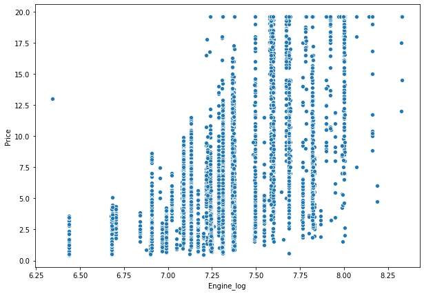

```python
plt.figure(figsize=(10,7))
sns.scatterplot(y="Price", x="Engine_log", data=df);
```

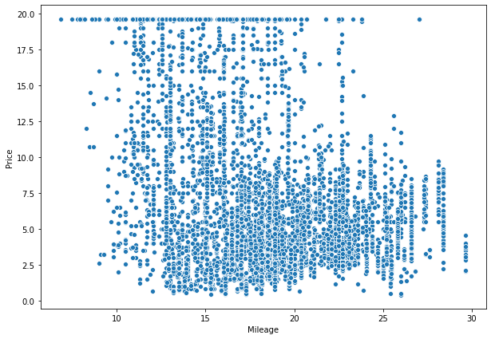

```python
plt.figure(figsize=(10,7))
sns.scatterplot(y="Price", x="Mileage", data=df);
```

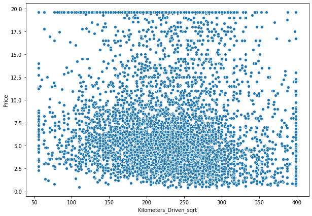

```python
plt.figure(figsize=(10,7))
sns.scatterplot(y="Price", x="Kilometers_Driven_sqrt", data=df);
```

##### Observations

- The graphs above indicate a positive relationship between Engine (the displacement volume of the engine) and Price as well as between Power (the maximum power of the engine) and Price
- The scatterplots for Mileage and Kilometers Driven indicate there is not a strong correlation between these and the target variable Price

```python
# Function to create barplots that indicate count.
def count_on_bar(data, z):
    """
    plot
    feature: categorical feature
    the function won't work if a column is passed in hue parameter
    """

    total = len(data[z])  # length of the column
    plt.figure(figsize=(15, 5))
    plt.xticks(rotation=45)
    ax = sns.countplot(data=data, x=z, palette="Paired")
    for p in ax.patches:
        percentage = p.get_height()  # count of each class of the category
        x = p.get_x() + p.get_width() / total + 0.2  # width of the plot
        y = p.get_y() + p.get_height()  # height of the plot

        ax.annotate(percentage, (x, y), size=12)  # annotate the percentage
    plt.show()  # show the plot
```

```python
df.groupby("Year")["Price"].describe()
```

| Year | count | mean | std | min | 25% | 50% | 75% | max |
| --- | --- | --- | --- | --- | --- | --- | --- | --- |
| 1998 | 4.000 | 1.432 | 1.654 | 0.450 | 0.510 | 0.690 | 1.612 | 3.900 |
| 1999 | 2.000 | 0.835 | 0.092 | 0.770 | 0.802 | 0.835 | 0.868 | 0.900 |
| 2000 | 4.000 | 1.175 | 0.664 | 0.550 | 0.662 | 1.100 | 1.613 | 1.950 |
| 2001 | 8.000 | 1.544 | 1.499 | 0.550 | 0.700 | 0.875 | 1.637 | 5.000 |
| 2002 | 15.000 | 1.294 | 0.801 | 0.510 | 0.725 | 1.200 | 1.650 | 3.650 |
| 2003 | 17.000 | 2.440 | 3.796 | 0.500 | 0.850 | 1.250 | 1.700 | 16.110 |
| 2004 | 31.000 | 1.941 | 1.503 | 0.450 | 1.050 | 1.400 | 2.215 | 7.100 |
| 2005 | 57.000 | 2.027 | 1.878 | 0.450 | 1.000 | 1.300 | 2.450 | 10.000 |
| 2006 | 78.000 | 2.851 | 3.368 | 0.690 | 1.377 | 1.750 | 2.612 | 19.625 |
| 2007 | 125.000 | 3.129 | 3.005 | 0.750 | 1.450 | 2.000 | 3.600 | 19.625 |
| 2008 | 174.000 | 3.756 | 3.390 | 0.600 | 1.800 | 2.535 | 4.000 | 19.625 |
| 2009 | 198.000 | 5.054 | 4.395 | 0.750 | 2.250 | 3.100 | 7.438 | 19.625 |
| 2010 | 342.000 | 5.089 | 4.638 | 0.500 | 2.277 | 3.000 | 5.845 | 19.625 |
| 2011 | 466.000 | 6.072 | 4.939 | 0.440 | 2.785 | 3.830 | 7.500 | 19.625 |
| 2012 | 580.000 | 6.688 | 5.193 | 0.530 | 3.200 | 4.500 | 7.562 | 19.625 |
| 2013 | 649.000 | 7.613 | 5.666 | 1.200 | 3.650 | 5.000 | 9.060 | 19.625 |
| 2014 | 797.000 | 8.273 | 5.812 | 1.000 | 4.250 | 5.750 | 10.500 | 19.625 |
| 2015 | 744.000 | 8.874 | 5.901 | 1.500 | 4.672 | 6.215 | 12.310 | 19.625 |
| 2016 | 741.000 | 9.145 | 5.640 | 1.800 | 5.100 | 6.990 | 12.000 | 19.625 |
| 2017 | 587.000 | 10.210 | 5.662 | 1.600 | 5.855 | 8.200 | 14.655 | 19.625 |
| 2018 | 298.000 | 10.837 | 5.470 | 2.900 | 6.578 | 8.755 | 16.505 | 19.625 |
| 2019 | 102.000 | 12.587 | 6.040 | 2.020 | 6.947 | 11.520 | 19.625 | 19.625 |

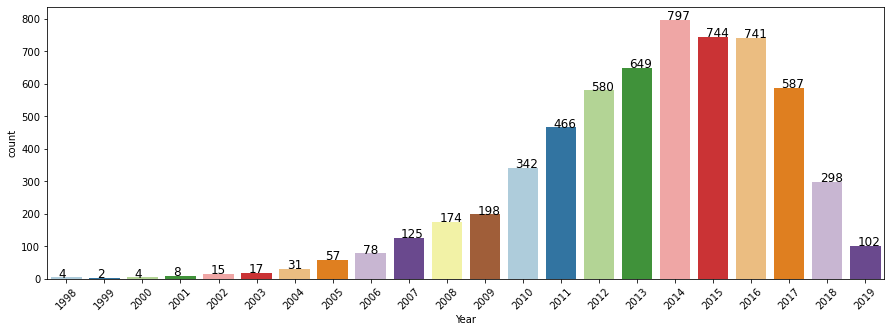

```python
count_on_bar(df, "Year")
```

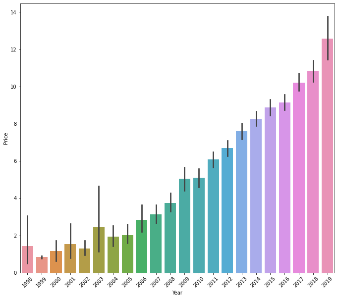

```python
plt.figure(figsize=(25, 10))

plt.subplot(1, 2, 1)
sns.barplot(data=df, y="Price", x="Year")
plt.xticks(rotation=45)

plt.show()
```

##### Observations

# Examining categorical variables

```python
#creating a list of the categorical features
cat_cols = []
for colname in df.columns[df.dtypes == 'category']:  # only need to consider string columns
    cat_cols.append(colname)

print(cat_cols)
```

```
['Name', 'Location', 'Fuel_Type', 'Transmission', 'Owner_Type', 'Brand']
```

#### Location

```python
df.groupby("Location")["Price"].describe()
```

| Location | count | mean | std | min | 25% | 50% | 75% | max |
| --- | --- | --- | --- | --- | --- | --- | --- | --- |
| Ahmedabad | 224.000 | 7.692 | 5.398 | 0.750 | 3.787 | 5.900 | 10.600 | 19.625 |
| Bangalore | 358.000 | 9.866 | 6.591 | 1.350 | 4.450 | 6.850 | 18.438 | 19.625 |
| Chennai | 494.000 | 6.526 | 5.384 | 0.650 | 2.800 | 4.500 | 7.500 | 19.625 |
| Coimbatore | 636.000 | 10.673 | 6.086 | 1.680 | 5.695 | 8.305 | 18.608 | 19.625 |
| Delhi | 554.000 | 7.922 | 5.773 | 0.750 | 3.600 | 5.500 | 11.000 | 19.625 |
| Hyderabad | 742.000 | 7.915 | 5.854 | 0.600 | 3.550 | 5.800 | 9.998 | 19.625 |
| Jaipur | 413.000 | 5.487 | 4.595 | 0.450 | 2.500 | 4.250 | 6.500 | 19.625 |
| Kochi | 651.000 | 8.958 | 5.689 | 1.260 | 4.775 | 6.710 | 11.795 | 19.625 |
| Kolkata | 535.000 | 5.142 | 4.233 | 0.650 | 2.600 | 3.750 | 5.875 | 19.625 |
| Mumbai | 790.000 | 7.915 | 5.639 | 0.550 | 3.750 | 5.750 | 10.082 | 19.625 |
| Pune | 622.000 | 6.057 | 5.074 | 0.440 | 2.743 | 4.250 | 7.445 | 19.625 |

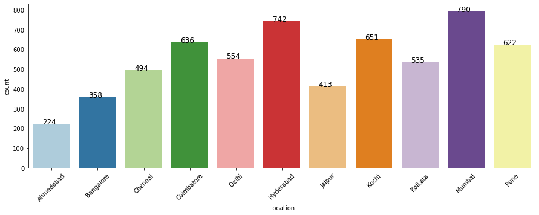

```python
count_on_bar(df, "Location")
```

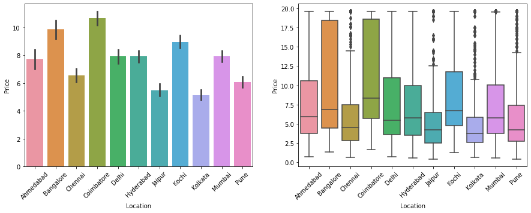

```python
plt.figure(figsize=(15, 5))

plt.subplot(1, 2, 1)
sns.barplot(data=df, y="Price", x="Location")
plt.xticks(rotation=45)

plt.subplot(1, 2, 2)
sns.boxplot(data=df, y="Price", x="Location")
plt.xticks(rotation=45)

plt.show()
```

##### Observations

- It looks like most sales have been reported from Mumbai and Hyderabad
- We also observe the lowest used car prices in Kolkata and Jaipur (means and mid 50% price distributions at the lower end of the scale).
- We see the widest range of prices in Bangalore and Coimbatore, the highest price means observed in these two cities as well.

#### Fuel Type

```python
df.groupby("Fuel_Type")["Price"].mean().sort_values(ascending=False)
```

```
Fuel_Type
Electric   12.875
Diesel      9.998
Petrol      5.137
CNG         3.517
LPG         2.487
Name: Price, dtype: float64
```

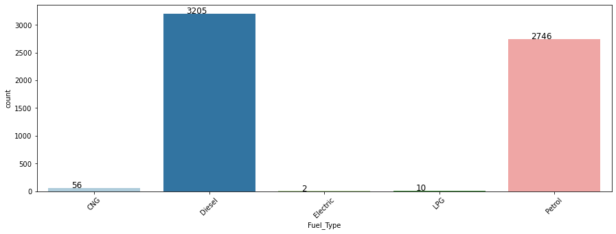

```python
count_on_bar(df, "Fuel_Type")
```

```python
df.Fuel_Type.value_counts(normalize=True, ascending=True)
```

```
Electric   0.000
LPG        0.002
CNG        0.009
Petrol     0.456
Diesel     0.532
Name: Fuel_Type, dtype: float64
```

We could consider here Electric, CNG, and LPG outlier categories given their very low frequency. We will then substitute these for the most popular fuel type: Diesel.

```python
df.groupby("Fuel_Type")["Price"].describe()
```

| Fuel_Type | count | mean | std | min | 25% | 50% | 75% | max |
| --- | --- | --- | --- | --- | --- | --- | --- | --- |
| CNG | 56.000 | 3.517 | 1.434 | 1.200 | 2.850 | 3.250 | 3.822 | 8.350 |
| Diesel | 3205.000 | 9.998 | 6.196 | 0.600 | 4.850 | 7.750 | 16.500 | 19.625 |
| Electric | 2.000 | 12.875 | 0.177 | 12.750 | 12.812 | 12.875 | 12.938 | 13.000 |
| LPG | 10.000 | 2.487 | 0.649 | 1.450 | 2.030 | 2.600 | 3.038 | 3.200 |
| Petrol | 2746.000 | 5.137 | 3.863 | 0.440 | 2.743 | 4.105 | 6.158 | 19.625 |

```python
df["Fuel_Type"] = df["Fuel_Type"].str.upper()
not_petrol = []

df["Fuel_Type"].replace({"CNG": "DIESEL", "LPG": "DIESEL", "ELECTRIC": "DIESEL"}, inplace=True)

df["Fuel_Type"] = df["Fuel_Type"].str.title()
```

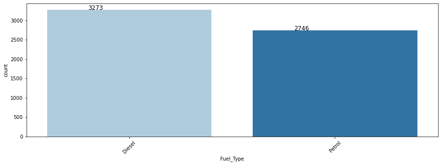

```python
    count_on_bar(df, "Fuel_Type")
```

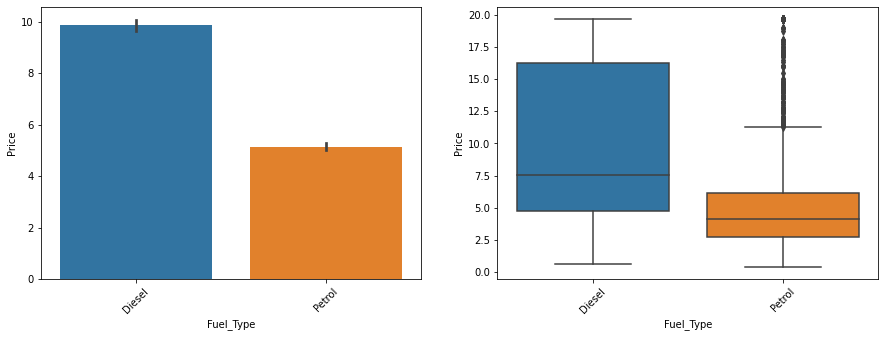

```python
plt.figure(figsize=(15, 5))

plt.subplot(1, 2, 1)
sns.barplot(data=df, y="Price", x="Fuel_Type")
plt.xticks(rotation=45)

plt.subplot(1, 2, 2)
sns.boxplot(data=df, y="Price", x="Fuel_Type")
plt.xticks(rotation=45)

plt.show()
```

##### Observations

- The most popular fuel type is Diesel followed by Petrol*
- Petrol cars have a lower mean price (5.14) as well as a narrower range of mid 50% distributions with presence of outliers on the high/left end of the distribution
- The IQR range for the Diesel distribution is wider and we observe a mean price, 9.86, considerably higher than Petrol cars

#### Transmission

```python
df.groupby("Transmission")["Price"].describe()
```

| Transmission | count | mean | std | min | 25% | 50% | 75% | max |
| --- | --- | --- | --- | --- | --- | --- | --- | --- |
| Automatic | 1720.000 | 13.754 | 6.119 | 1.500 | 7.973 | 16.000 | 19.625 | 19.625 |
| Manual | 4299.000 | 5.290 | 3.342 | 0.440 | 3.000 | 4.500 | 6.545 | 19.625 |

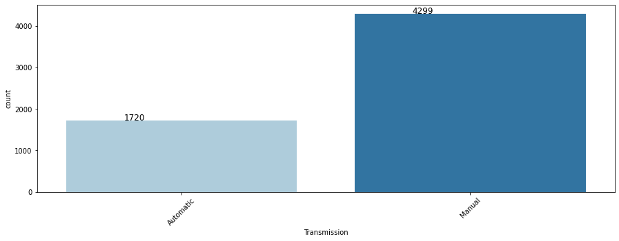

```python
count_on_bar(df, "Transmission")
```

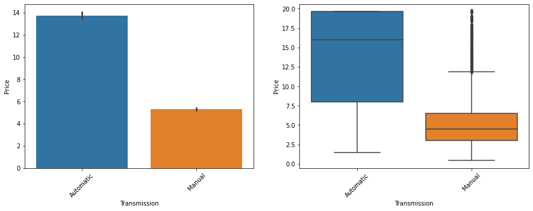

```python
plt.figure(figsize=(15, 5))

plt.subplot(1, 2, 1)
sns.barplot(data=df, y="Price", x="Transmission")
plt.xticks(rotation=45)

plt.subplot(1, 2, 2)
sns.boxplot(data=df, y="Price", x="Transmission")
plt.xticks(rotation=45)

plt.show()
```

##### Observations

With 71.4% of cars in the dataset, the most popular transmission type is Manual

Manual cars are considerably cheaper than Automatic, with a mean price of 5.29 compared to 13.75

The IQR price range for Automatic cars is wider and spans a higher range of prices, 7.97 for Q1 and 19.63 for Q3

Manual car prices’ IQR range: Q1 = 3, Q3 = 6.55. We also observe the presence of outliers: manual cars with prices above the top whisker value (Q3 + 1.5 IQR) of 11.86

#### Owner Type

```python
df.groupby("Owner_Type")["Price"].describe()
```

| Owner_Type | count | mean | std | min | 25% | 50% | 75% | max |
| --- | --- | --- | --- | --- | --- | --- | --- | --- |
| First | 4929.000 | 8.044 | 5.759 | 0.500 | 3.750 | 5.910 | 10.500 | 19.625 |
| Fourth & Above | 9.000 | 3.280 | 1.316 | 1.970 | 2.200 | 3.000 | 4.000 | 5.500 |
| Second | 968.000 | 6.487 | 5.683 | 0.440 | 2.450 | 4.270 | 8.250 | 19.625 |
| Third | 113.000 | 3.901 | 4.081 | 0.450 | 1.300 | 2.650 | 4.200 | 19.625 |

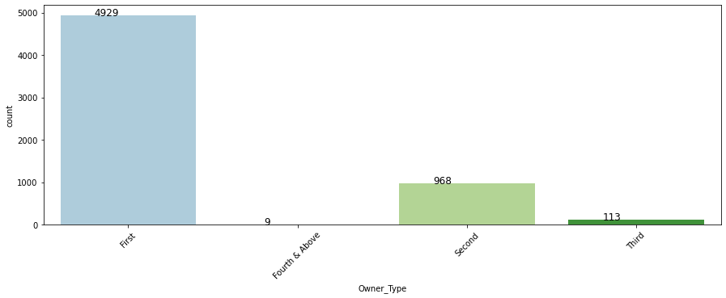

```python
count_on_bar(df, "Owner_Type")
```

```python
df.Owner_Type.value_counts(normalize=True, ascending=True)
```

```
Fourth & Above   0.001
Third            0.019
Second           0.161
First            0.819
Name: Owner_Type, dtype: float64
```

##### Observations

82% of used cars in this sample are classified as "First" owner_type. To account for the skewness here, we can split the category into 2 types, First and Second & Above. This will not solve the skewness in the distribution of values in the category but will attenuate it.

```python
df["Owner_Type"] = df["Owner_Type"].str.upper()

df["Owner_Type"].replace({"SECOND": "SECOND & ABOVE", "THIRD": "SECOND & ABOVE", "FOURTH & ABOVE": "SECOND & ABOVE"}, inplace=True)

df["Owner_Type"] = df["Owner_Type"].str.title()
```

```python
df.groupby("Owner_Type")["Price"].describe()
```

| Owner_Type | count | mean | std | min | 25% | 50% | 75% | max |
| --- | --- | --- | --- | --- | --- | --- | --- | --- |
| First | 4929.000 | 8.044 | 5.759 | 0.500 | 3.750 | 5.910 | 10.500 | 19.625 |
| Second & Above | 1090.000 | 6.192 | 5.576 | 0.440 | 2.305 | 4.000 | 7.742 | 19.625 |

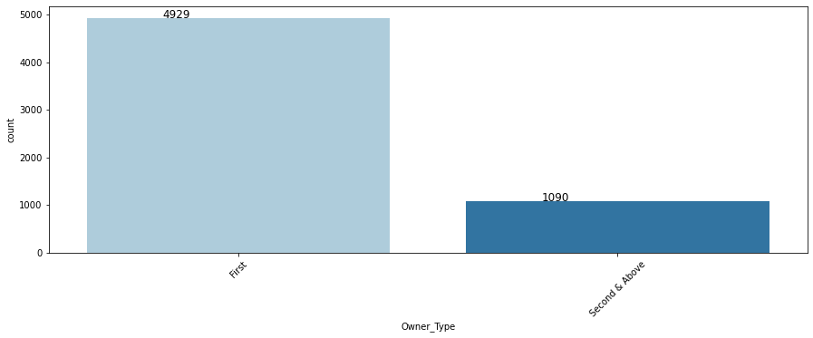

```python
count_on_bar(df, "Owner_Type")
```

```python
df.Owner_Type.value_counts(normalize=True, ascending=True)
```

```
Second & Above   0.181
First            0.819
Name: Owner_Type, dtype: float64
```

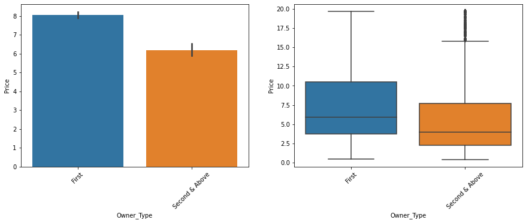

```python
plt.figure(figsize=(15, 5))

plt.subplot(1, 2, 1)
sns.barplot(data=df, y="Price", x="Owner_Type")
plt.xticks(rotation=45)

plt.subplot(1, 2, 2)
sns.boxplot(data=df, y="Price", x="Owner_Type")
plt.xticks(rotation=45)

plt.show()
```

##### Observations

```python
df.groupby("Brand")["Price"].describe()
```

| Brand | count | mean | std | min | 25% | 50% | 75% | max |
| --- | --- | --- | --- | --- | --- | --- | --- | --- |
| Audi | 262.000 | 17.905 | 3.207 | 7.500 | 17.812 | 19.625 | 19.625 | 19.625 |
| BMW | 303.000 | 16.854 | 3.879 | 6.300 | 14.160 | 19.625 | 19.625 | 19.625 |
| Chevrolet | 121.000 | 3.044 | 1.828 | 0.750 | 1.750 | 2.500 | 3.700 | 9.870 |
| Fiat | 29.000 | 3.260 | 1.868 | 0.550 | 2.200 | 2.600 | 4.650 | 7.710 |
| Ford | 300.000 | 6.040 | 4.609 | 0.690 | 2.750 | 5.345 | 7.342 | 19.625 |
| Honda | 608.000 | 5.412 | 2.541 | 0.900 | 3.540 | 4.950 | 6.585 | 17.500 |
| Hyundai | 1107.000 | 5.334 | 3.269 | 0.450 | 3.095 | 4.600 | 6.450 | 19.625 |
| Jaguar | 59.000 | 19.127 | 2.435 | 2.020 | 19.625 | 19.625 | 19.625 | 19.625 |
| Land | 61.000 | 18.873 | 1.761 | 11.000 | 19.625 | 19.625 | 19.625 | 19.625 |
| Mahindra | 275.000 | 8.060 | 3.587 | 1.500 | 5.500 | 7.650 | 10.085 | 17.630 |
| Maruti | 1211.000 | 4.517 | 2.296 | 0.450 | 2.800 | 4.150 | 5.995 | 11.500 |
| Mercedes-Benz | 318.000 | 16.966 | 4.000 | 3.900 | 14.500 | 19.625 | 19.625 | 19.625 |
| Nissan | 104.000 | 4.527 | 1.745 | 1.750 | 3.000 | 4.000 | 5.882 | 8.920 |
| Renault | 145.000 | 5.799 | 2.385 | 2.400 | 3.800 | 5.490 | 7.100 | 14.010 |
| Skoda | 173.000 | 7.417 | 4.584 | 1.250 | 4.250 | 6.000 | 9.720 | 19.625 |
| Tata | 187.000 | 3.551 | 2.691 | 0.440 | 1.640 | 2.900 | 4.560 | 17.850 |
| Toyota | 441.000 | 10.979 | 5.807 | 1.000 | 5.600 | 10.750 | 16.500 | 19.625 |
| Volkswagen | 315.000 | 5.291 | 2.342 | 2.100 | 3.750 | 4.890 | 6.155 | 19.625 |

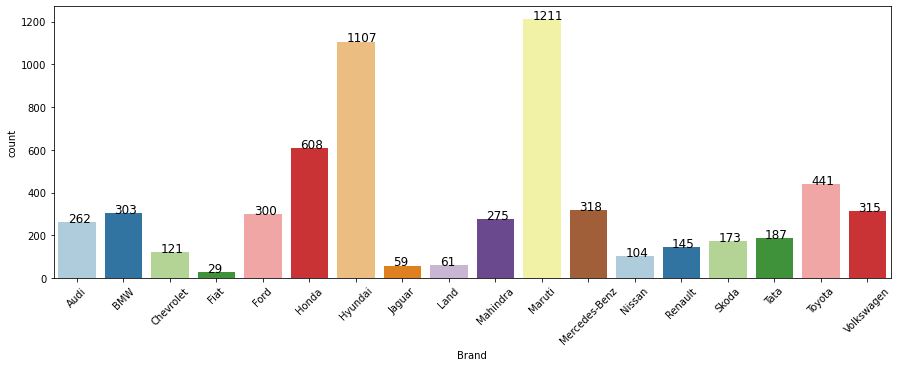

```python
count_on_bar(df, "Brand")
```

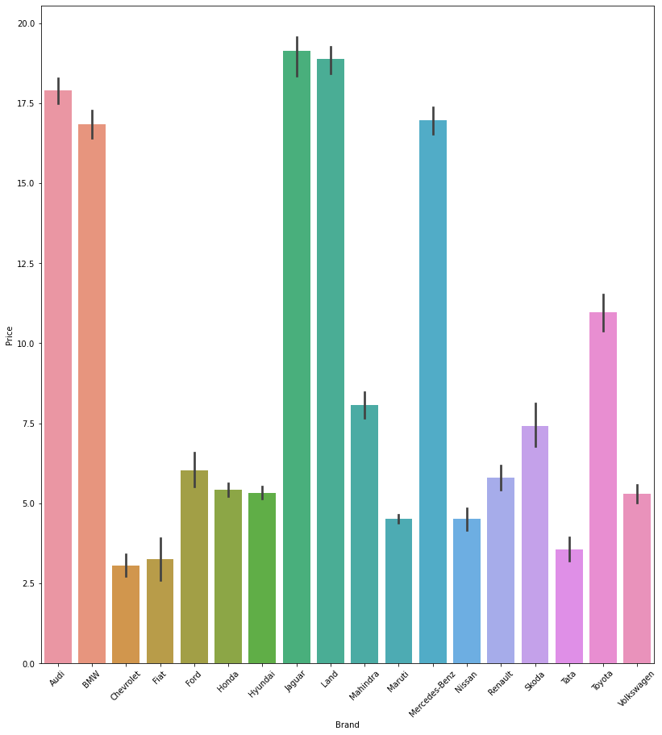

```python
plt.figure(figsize=(30, 15))

plt.subplot(1, 2, 1)
sns.barplot(data=df, y="Price", x="Brand")
plt.xticks(rotation=45)

plt.show()
```

##### Observations:

Hyundai and Maruti are the most popular brands

- European luxury brands like Land Rover, Jaguar, and Audi show up as the most expensive
- Chevrolet has the lowest mean price (3.04 Lakh), followed by Fiat (3.26) and Tata (3.55)

```python
df.Fuel_Type = df.Fuel_Type.astype('category')
df.Owner_Type = df.Owner_Type.astype('category')
```

```python
df.info()
```

```
<class 'pandas.core.frame.DataFrame'>
Int64Index: 6019 entries, 0 to 6018
Data columns (total 14 columns):
 #   Column                  Non-Null Count  Dtype
---  ------                  --------------  -----
 0   Name                    6019 non-null   category
 1   Location                6019 non-null   category
 2   Year                    6019 non-null   int64
 3   Fuel_Type               6019 non-null   category
 4   Transmission            6019 non-null   category
 5   Owner_Type              6019 non-null   category
 6   Mileage                 6019 non-null   float64
 7   Seats                   6019 non-null   float64
 8   New_Price               6019 non-null   float64
 9   Price                   6019 non-null   float64
 10  Brand                   6019 non-null   category
 11  Kilometers_Driven_sqrt  6019 non-null   float64
 12  Engine_log              6019 non-null   float64
 13  Power_log               6019 non-null   float64
dtypes: category(6), float64(7), int64(1)
memory usage: 720.5 KB
```

## Creating Dummy Variables

```python
df.Name.nunique()
```

```
1876
```

```python
#creating a list of the categorical features
cat_cols = []
for colname in df.columns[df.dtypes == 'category']:  # only need to consider string columns
    cat_cols.append(colname)

cat_cols.remove("Name")
cat_cols.remove("Brand")
print(cat_cols)
```

```
['Location', 'Fuel_Type', 'Transmission', 'Owner_Type']
```

```python
df = pd.get_dummies(df,columns=cat_cols,drop_first=True)
```

```python
df = pd.get_dummies(df,columns=["Brand"],drop_first=False) # will drop one of the dummies manually - see below
```

##### Observations

We observe too large of a number of unique values for the Name category to encode into dummy variables. We will use one-hot encoding for the remaining categorical variables to assist us in model building.

Note that no dummy has yet been dropped for the ones created for Brand variable. We will manually drop one of the dummies, the one with the lowest mean price ("Brand_Chevrolet"), to help later on with the interpretation of the linear equation coefficients.

## Data Preparation for Modeling

```python
# defining X and y variables
#choosing to drop manually brand chevrolet to help with model interpretation since Chevrolet has the lowest
#mean price of all the brands
X = df.drop(["Price", "Name", "New_Price", "Seats", "Brand_Chevrolet"], axis=1)
y = df[["Price"]]

print(X.head())
print(y.head())
```

```
       Year  Mileage  Kilometers_Driven_sqrt  Engine_log  Power_log  \
S.No.
0      2010   26.600                 268.328       6.906      4.063
1      2015   19.670                 202.485       7.366      4.838
2      2011   18.200                 214.476       7.089      4.485
3      2012   20.770                 294.958       7.129      4.486
4      2013   15.200                 201.668       7.585      4.947

       Location_Bangalore  Location_Chennai  Location_Coimbatore  \
S.No.
0                       0                 0                    0
1                       0                 0                    0
2                       0                 1                    0
3                       0                 1                    0
4                       0                 0                    1

       Location_Delhi  Location_Hyderabad  Location_Jaipur  Location_Kochi  \
S.No.
0                   0                   0                0               0
1                   0                   0                0               0
2                   0                   0                0               0
3                   0                   0                0               0
4                   0                   0                0               0

       Location_Kolkata  Location_Mumbai  Location_Pune  Fuel_Type_Petrol  \
S.No.
0                     0                1              0                 0
1                     0                0              1                 0
2                     0                0              0                 1
3                     0                0              0                 0
4                     0                0              0                 0

       Transmission_Manual  Owner_Type_Second & Above  Brand_Audi  Brand_BMW  \
S.No.
0                        1                          0           0          0
1                        1                          0           0          0
2                        1                          0           0          0
3                        1                          0           0          0
4                        0                          1           1          0

```

[output cut: 23 more lines]

```

       Brand_Volkswagen
S.No.
0                     0
1                     0
2                     0
3                     0
4                     0
       Price
S.No.
0      1.750
1     12.500
2      4.500
3      6.000
4     17.740
```

```python
print(X.shape)
print(y.shape)
```

```
(6019, 35)
(6019, 1)
```

```python
# split the data into train and test
from sklearn.model_selection import train_test_split

X_train, X_test, y_train, y_test = train_test_split(
    X, y, test_size=0.3, random_state=42
)
```

```python
X_train.head()
```

| S.No. | Year | Mileage | Kilometers_Driven_sqrt | Engine_log | Power_log | Location_Bangalore | Location_Chennai | Location_Coimbatore | Location_Delhi | Location_Hyderabad | Location_Jaipur | Location_Kochi | Location_Kolkata | Location_Mumbai | Location_Pune | Fuel_Type_Petrol | Transmission_Manual | Owner_Type_Second & Above | Brand_Audi | Brand_BMW | Brand_Fiat | Brand_Ford | Brand_Honda | Brand_Hyundai | Brand_Jaguar | Brand_Land | Brand_Mahindra | Brand_Maruti | Brand_Mercedes-Benz | … |
| --- | --- | --- | --- | --- | --- | --- | --- | --- | --- | --- | --- | --- | --- | --- | --- | --- | --- | --- | --- | --- | --- | --- | --- | --- | --- | --- | --- | --- | --- | --- |
| 4201 | 2011 | 22.070 | 277.489 | 7.089 | 4.303 | 0 | 0 | 0 | 0 | 0 | 1 | 0 | 0 | 0 | 0 | 0 | 1 | 0 | 0 | 0 | 0 | 0 | 0 | 0 | 0 | 0 | 0 | 0 | 0 | … |
| 4383 | 2016 | 20.360 | 141.234 | 7.088 | 4.368 | 0 | 0 | 0 | 0 | 1 | 0 | 0 | 0 | 0 | 0 | 1 | 1 | 0 | 0 | 0 | 0 | 0 | 0 | 1 | 0 | 0 | 0 | 0 | 0 | … |
| 1779 | 2014 | 15.100 | 266.389 | 7.687 | 4.942 | 0 | 0 | 0 | 0 | 0 | 0 | 1 | 0 | 0 | 0 | 0 | 1 | 0 | 0 | 0 | 0 | 0 | 0 | 0 | 0 | 0 | 1 | 0 | 0 | … |
| 4020 | 2013 | 25.200 | 339.404 | 7.129 | 4.304 | 0 | 0 | 0 | 0 | 0 | 0 | 0 | 1 | 0 | 0 | 0 | 1 | 0 | 0 | 0 | 0 | 0 | 0 | 0 | 0 | 0 | 0 | 1 | 0 | … |
| 3248 | 2011 | 16.470 | 242.388 | 7.088 | 4.303 | 0 | 0 | 0 | 0 | 0 | 0 | 1 | 0 | 0 | 0 | 1 | 1 | 0 | 0 | 0 | 0 | 0 | 0 | 0 | 0 | 0 | 0 | 0 | 0 | … |

# Choose, train and evaluate the model

```python
# To build linear regression_model
from sklearn.linear_model import LinearRegression

# To check model performance
from sklearn.metrics import mean_absolute_error, mean_squared_error, r2_score

#additional libraries to be used
import statsmodels.stats.api as sms
from statsmodels.compat import lzip
import statsmodels.api as sm
```

```python
# fitting the model on the train data (70% of the whole data)
linearregression = LinearRegression()
linearregression.fit(X_train, y_train)
```

```
LinearRegression()
```

```python
# let us check the coefficients and intercept of the model

coef_df = pd.DataFrame(
    np.append(linearregression.coef_[0], linearregression.intercept_[0]),
    index=X_train.columns.tolist() + ["Intercept"],
    columns=["Coefficients"],
)

coef_df
```

|  | Coefficients |
| --- | --- |
| Year | 0.561 |
| Mileage | -0.170 |
| Kilometers_Driven_sqrt | -0.006 |
| Engine_log | 0.678 |
| Power_log | 3.914 |
| Location_Bangalore | 0.641 |
| Location_Chennai | 0.105 |
| Location_Coimbatore | 0.456 |
| Location_Delhi | -0.630 |
| Location_Hyderabad | 0.511 |
| Location_Jaipur | 0.104 |
| Location_Kochi | -0.215 |
| Location_Kolkata | -1.405 |
| Location_Mumbai | -0.468 |
| Location_Pune | -0.148 |
| Fuel_Type_Petrol | -1.851 |
| Transmission_Manual | -1.280 |
| Owner_Type_Second & Above | -0.303 |
| Brand_Audi | 7.740 |
| Brand_BMW | 6.892 |
| Brand_Fiat | 0.395 |
| Brand_Ford | 1.196 |
| Brand_Honda | 0.981 |
| Brand_Hyundai | 1.258 |
| Brand_Jaguar | 7.924 |
| Brand_Land | 8.471 |
| Brand_Mahindra | 0.824 |
| Brand_Maruti | 1.609 |
| Brand_Mercedes-Benz | 6.621 |
| Brand_Nissan | 0.570 |
| Brand_Renault | 0.814 |
| Brand_Skoda | 1.503 |
| Brand_Tata | -0.185 |
| Brand_Toyota | 4.160 |
| Brand_Volkswagen | 0.530 |
| Intercept | -1140.565 |

**Let's check the performance of the model using different metrics (MAE, MAPE, RMSE, $R^2$).**

- We will be using metric functions defined in sklearn for RMSE, MAE, and $R^2$.
- We will define a function to calculate MAPE.
- We will create a function which will print out all the above metrics in one go.

```python
# defining function for MAPE
def mape(targets, predictions):
    return np.mean(np.abs((targets - predictions)) / targets) * 100


# defining common function for all metrics
def model_perf(model, inp, out):
    """
    model: model
    inp: independent variables
    out: dependent variable
    """
    y_pred = model.predict(inp).flatten()
    y_act = out.values.flatten()

    return pd.DataFrame(
        {
            "MAE": mean_absolute_error(y_act, y_pred),
            "MAPE": mape(y_act, y_pred),
            "RMSE": np.sqrt(mean_squared_error(y_act, y_pred)),
            "R^2": r2_score(y_act, y_pred),
        },
        index=[0],
    )
```

```python
# Checking model performance on train set (seen 70% data)
print("Train Performance\n")
model_perf(linearregression, X_train, y_train)
```

```
Train Performance
```

|  | MAE | MAPE | RMSE | R^2 |
| --- | --- | --- | --- | --- |
| 0 | 1.371 | 30.575 | 1.879 | 0.893 |

```python
# Checking model performance on test set (unseen 30% data)
print("Test Performance\n")
model_perf(linearregression, X_test, y_test)
```

```
Test Performance
```

|  | MAE | MAPE | RMSE | R^2 |
| --- | --- | --- | --- | --- |
| 0 | 1.410 | 32.782 | 1.964 | 0.886 |

- The mean absolute percentage error (MAPE) measures the accuracy of predictions as a percentage, and can be calculated as the average absolute percent error for each predicted value minus actual values divided by actual values. It works best if there are no extreme values in the data and none of the actual values are 0.
- The mean absolute error (MAE) is the simplest regression error metric to understand. We'll calculate the residual for every data point, taking only the absolute value of each so that negative and positive residuals do not cancel out. We then take the average of all these residuals. Effectively, MAE describes the typical magnitude of the residuals.
- The root mean square error (RMSE) is just like the MAE, but squares the difference before summing them all instead of using the absolute value, and then takes the square root of the value.
- $R^2$ (or coefficient of determination) represents the proportion of variance (of y) that has been explained by the independent variables in the model. It provides an indication of goodness of fit of the model. Best possible score is 1.0 and it can be negative (because the model can be arbitrarily worse). A constant model that always predicts the expected value (or mean) of y, disregarding the input features, would get a $R^2$ of 0.0.

**Observations**

- The training and testing scores are 89.3% and 88.6% respectively, and both the scores are comparable. Hence, the model is a good fit.
- R-squared is 0.886 on the test set, i.e., the model explains 88.6.3% of total variation in the test dataset. So, overall the model is very satisfactory.
- MAE indicates that our current model is able to predict price within a mean error of 1.410 Lakh on the test data.
- MAPE on the test set suggests we can predict within 32.78% of the price.

# Linear Regression using statsmodels

- We have build a linear regression model which shows good performance on the train and test sets.
- But this is **not** the final model.
- We have to check the statistical validity of the model, and also make sure it satisfies the assumptions of linear regression.
- We will now perform linear regression using *statsmodels*, a Python module that provides functions for the estimation of many statistical models, as well as for conducting statistical tests, and statistical data exploration.
- Using statsmodels, we will be able to check the statistical validity of the model.

```python
# Let's build linear regression model using statsmodel
# unlike sklearn, statsmodels does not add a constant to the data on its own
# we have to add the constant manually
X = sm.add_constant(X)
X_train1, X_test, y_train, y_test = train_test_split(
    X, y, test_size=0.3, random_state=42
)

olsmod1 = sm.OLS(y_train, X_train1)
olsres1 = olsmod1.fit()
print(olsres1.summary())
```

```
                            OLS Regression Results
==============================================================================
Dep. Variable:                  Price   R-squared:                       0.893
Model:                            OLS   Adj. R-squared:                  0.892
Method:                 Least Squares   F-statistic:                     997.0
Date:                Tue, 06 Jul 2021   Prob (F-statistic):               0.00
Time:                        14:15:05   Log-Likelihood:                -8634.6
No. Observations:                4213   AIC:                         1.734e+04
Df Residuals:                    4177   BIC:                         1.757e+04
Df Model:                          35
Covariance Type:            nonrobust
=============================================================================================
                                coef    std err          t      P>|t|      [0.025      0.975]
---------------------------------------------------------------------------------------------
const                     -1140.5653     26.373    -43.248      0.000   -1192.270   -1088.861
Year                          0.5609      0.013     42.814      0.000       0.535       0.587
Mileage                      -0.1698      0.014    -12.530      0.000      -0.196      -0.143
Kilometers_Driven_sqrt       -0.0065      0.001    -10.777      0.000      -0.008      -0.005
Engine_log                    0.6780      0.292      2.319      0.020       0.105       1.251
Power_log                     3.9142      0.210     18.646      0.000       3.503       4.326
Location_Bangalore            0.6411      0.193      3.315      0.001       0.262       1.020
Location_Chennai              0.1052      0.185      0.567      0.571      -0.258       0.469
Location_Coimbatore           0.4557      0.179      2.543      0.011       0.104       0.807
Location_Delhi               -0.6295      0.181     -3.483      0.001      -0.984      -0.275
Location_Hyderabad            0.5106      0.175      2.922      0.004       0.168       0.853
Location_Jaipur               0.1041      0.190      0.546      0.585      -0.269       0.478
Location_Kochi               -0.2152      0.178     -1.206      0.228      -0.565       0.135
Location_Kolkata             -1.4051      0.183     -7.684      0.000      -1.764      -1.047
Location_Mumbai              -0.4683      0.175     -2.679      0.007      -0.811      -0.126
Location_Pune                -0.1480      0.178     -0.829      0.407      -0.498       0.202
Fuel_Type_Petrol             -1.8506      0.101    -18.401      0.000      -2.048      -1.653
Transmission_Manual          -1.2801      0.095    -13.409      0.000      -1.467      -1.093
Owner_Type_Second & Above    -0.3030      0.084     -3.616      0.000      -0.467      -0.139
Brand_Audi                    7.7396      0.273     28.369      0.000       7.205       8.274
Brand_BMW                     6.8919      0.270     25.567      0.000       6.363       7.420
Brand_Fiat                    0.3954      0.491      0.805      0.421      -0.568       1.359
Brand_Ford                    1.1958      0.247      4.843      0.000       0.712       1.680
Brand_Honda                   0.9807      0.232      4.236      0.000       0.527       1.435
Brand_Hyundai                 1.2575      0.220      5.724      0.000       0.827       1.688
Brand_Jaguar                  7.9239      0.388     20.423      0.000       7.163       8.685
Brand_Land                    8.4709      0.378     22.438      0.000       7.731       9.211
Brand_Mahindra                0.8241      0.261      3.154      0.002       0.312       1.336
Brand_Maruti                  1.6092      0.221      7.290      0.000       1.176       2.042
Brand_Mercedes-Benz           6.6206      0.265     24.964      0.000       6.101       7.141
Brand_Nissan                  0.5705      0.306      1.861      0.063      -0.030       1.171
Brand_Renault                 0.8136      0.286      2.841      0.005       0.252       1.375
Brand_Skoda                   1.5028      0.274      5.493      0.000       0.966       2.039
Brand_Tata                   -0.1847      0.269     -0.685      0.493      -0.713       0.344
Brand_Toyota                  4.1601      0.250     16.622      0.000       3.669       4.651
Brand_Volkswagen              0.5302      0.245      2.168      0.030       0.051       1.010
==============================================================================
Omnibus:                      291.498   Durbin-Watson:                   1.953
Prob(Omnibus):                  0.000   Jarque-Bera (JB):             1003.224
Skew:                           0.296   Prob(JB):                    1.42e-218
Kurtosis:                       5.316   Cond. No.                     1.84e+06
==============================================================================

Warnings:
[1] Standard Errors assume that the covariance matrix of the errors is correctly specified.
[2] The condition number is large, 1.84e+06. This might indicate that there are
strong multicollinearity or other numerical problems.
```

## Interpreting the Regression Results:

1. **Adjusted. R-squared**: It reflects the fit of the model.
   - Adjusted R-squared values generally range from 0 to 1, where a higher value generally indicates a better fit, assuming certain conditions are met.
   - In our case, the value for Adj. R-squared is **0.892**, which is good
1. *const* coefficient: It is the Y-intercept.
   - It means that if all the independent variable coefficients are zero, then the expected output (i.e., Y) would be equal to the *const* coefficient.
1. **Coefficient of an independent variable**: It represents the change in the output Y due to a change in the independent variable (everything else held constant).
1. **std err**: It reflects the level of accuracy of the coefficients.
   - The lower it is, the higher is the level of accuracy.
1. **P>|t|**: It is p-value.
   - For each independent feature, there is a null hypothesis and an alternate hypothesis. Here $\beta_i$ is the coefficient of the $i$th independent variable.
     - $H_o$ : Independent feature is not significant ($\beta_i = 0$)
     - $H_a$ : Independent feature is that it is significant ($\beta_i \neq 0$)
   - (P>|t|) gives the p-value for each independent feature to check that null hypothesis. We are considering 0.05 (5%) as significance level.
     - A p-value of less than 0.05 is considered to be statistically significant.
1. **Confidence Interval**: It represents the range in which our coefficients are likely to fall (with a likelihood of 95%).

**Observations**

- Negative values of the coefficient show that *Price* decreases with the increase of corresponding attribute value.
- Positive values of the coefficient show that *Price* increases with the increase of corresponding attribute value.
- p-value of a variable indicates if the variable is significant or not. If we consider the significance level to be 0.05 (5%), then any variable with a p-value less than 0.05 would be considered significant.
- But these variables might contain multicollinearity, which will affect the p-values.
- So, we need to deal with multicollinearity and check the other assumptions of linear regression first, and then look at the p-values.

# Checking Linear Regression Assumptions

We will be checking the following Linear Regression assumptions:

**1. No Multicollinearity**

**2. Mean of residuals should be 0**

**3. No Heteroscedasticity**

**4. Linearity of variables**

**5. Normality of error terms**

### TEST FOR MULTICOLLINEARITY

- Multicollinearity occurs when predictor variables in a regression model are correlated. This correlation is a problem because predictor variables should be independent. If the correlation between variables is high, it can cause problems when we fit the model and interpret the results. When we have multicollinearity the linear model, The coefficients that the model suggests are unreliable.
- There are different ways of detecting (or testing) multicollinearity. One such way is by using Variation Inflation Factor.
- **Variance Inflation factor**: Variance inflation factors measure the inflation in the variances of the regression parameter estimates due to collinearities that exist among the predictors. It is a measure of how much the variance of the estimated regression coefficient $\beta_k$ is "inflated" by the existence of correlation among the predictor variables in the model.
- **General Rule of thumb**: If VIF is 1 then there is no correlation among the $k$th predictor and the remaining predictor variables, and hence, the variance of $\beta_k$ is not inflated at all. Whereas, if VIF exceeds 5 or is close to exceeding 5, we say there is moderate multicollinearity, and if it is 10 or exceeding 10, it shows signs of high multicollinearity.

```python
from statsmodels.stats.outliers_influence import variance_inflation_factor

vif_series1 = pd.Series(
    [variance_inflation_factor(X.values, i) for i in range(X.shape[1])], index=X.columns
)
print("VIF Scores: \n\n{}\n".format(vif_series1))
```

```
VIF Scores:

const                       817520.235
Year                             2.156
Mileage                          3.684
Kilometers_Driven_sqrt           1.941
Engine_log                      11.269
Power_log                        8.608
Location_Bangalore               2.481
Location_Chennai                 2.993
Location_Coimbatore              3.532
Location_Delhi                   3.178
Location_Hyderabad               3.834
Location_Jaipur                  2.688
Location_Kochi                   3.582
Location_Kolkata                 3.148
Location_Mumbai                  4.011
Location_Pune                    3.442
Fuel_Type_Petrol                 2.944
Transmission_Manual              2.223
Owner_Type_Second & Above        1.229
Brand_Audi                       3.628
Brand_BMW                        4.097
Brand_Fiat                       1.238
Brand_Ford                       3.385
Brand_Honda                      5.664
Brand_Hyundai                    8.412
Brand_Jaguar                     1.688
Brand_Land                       1.648
Brand_Mahindra                   3.459
Brand_Maruti                     9.046
Brand_Mercedes-Benz              4.137
Brand_Nissan                     1.853
Brand_Renault                    2.182
Brand_Skoda                      2.477
Brand_Tata                       2.512
Brand_Toyota                     4.951
Brand_Volkswagen                 3.457
dtype: float64
```

#### Observartions

- VIF for Engine_log is higher than 10 (VIF: 11.269) so we will drop it from the model and examine the results

### Removing Multicollinearity

To remove multicollinearity

1. Drop every column one by one that has VIF score greater than 5.
2. Look at the adjusted R-squared of all these models.
3. Drop the variable that makes least change in adjusted R-squared.
4. Check the VIF scores again.
5. Continue till you get all VIF scores under 5.

```python
# we drop the one with the highest vif values and check the adjusted R-squared
X_train2 = X_train1.drop("Engine_log", axis=1)
vif_series2 = pd.Series(
    [variance_inflation_factor(X_train2.values, i) for i in range(X_train2.shape[1])],
    index=X_train2.columns,
)
print("VIF Scores: \n\n{}\n".format(vif_series2))
```

```
VIF Scores:

const                       814801.217
Year                             2.125
Mileage                          3.034
Kilometers_Driven_sqrt           1.927
Power_log                        4.095
Location_Bangalore               2.591
Location_Chennai                 3.004
Location_Coimbatore              3.599
Location_Delhi                   3.263
Location_Hyderabad               3.905
Location_Jaipur                  2.690
Location_Kochi                   3.659
Location_Kolkata                 3.216
Location_Mumbai                  4.065
Location_Pune                    3.524
Fuel_Type_Petrol                 2.202
Transmission_Manual              2.197
Owner_Type_Second & Above        1.228
Brand_Audi                       3.641
Brand_BMW                        4.073
Brand_Fiat                       1.214
Brand_Ford                       3.513
Brand_Honda                      5.668
Brand_Hyundai                    8.633
Brand_Jaguar                     1.667
Brand_Land                       1.624
Brand_Mahindra                   3.425
Brand_Maruti                     9.248
Brand_Mercedes-Benz              4.125
Brand_Nissan                     1.855
Brand_Renault                    2.139
Brand_Skoda                      2.513
Brand_Tata                       2.490
Brand_Toyota                     4.803
Brand_Volkswagen                 3.527
dtype: float64
```

```python
olsmod2 = sm.OLS(y_train, X_train2)
olsres2 = olsmod2.fit()
print(olsres2.summary())
```

```
                            OLS Regression Results
==============================================================================
Dep. Variable:                  Price   R-squared:                       0.893
Model:                            OLS   Adj. R-squared:                  0.892
Method:                 Least Squares   F-statistic:                     1025.
Date:                Tue, 06 Jul 2021   Prob (F-statistic):               0.00
Time:                        14:25:42   Log-Likelihood:                -8637.3
No. Observations:                4213   AIC:                         1.734e+04
Df Residuals:                    4178   BIC:                         1.757e+04
Df Model:                          34
Covariance Type:            nonrobust
=============================================================================================
                                coef    std err          t      P>|t|      [0.025      0.975]
---------------------------------------------------------------------------------------------
const                     -1134.4099     26.253    -43.211      0.000   -1185.879   -1082.941
Year                          0.5596      0.013     42.732      0.000       0.534       0.585
Mileage                      -0.1836      0.012    -15.073      0.000      -0.208      -0.160
Kilometers_Driven_sqrt       -0.0064      0.001    -10.707      0.000      -0.008      -0.005
Power_log                     4.2678      0.144     29.566      0.000       3.985       4.551
Location_Bangalore            0.6399      0.194      3.307      0.001       0.261       1.019
Location_Chennai              0.1062      0.186      0.572      0.567      -0.258       0.470
Location_Coimbatore           0.4585      0.179      2.557      0.011       0.107       0.810
Location_Delhi               -0.6288      0.181     -3.477      0.001      -0.983      -0.274
Location_Hyderabad            0.5110      0.175      2.922      0.003       0.168       0.854
Location_Jaipur               0.1058      0.191      0.555      0.579      -0.268       0.479
Location_Kochi               -0.2140      0.179     -1.198      0.231      -0.564       0.136
Location_Kolkata             -1.4044      0.183     -7.676      0.000      -1.763      -1.046
Location_Mumbai              -0.4610      0.175     -2.636      0.008      -0.804      -0.118
Location_Pune                -0.1415      0.179     -0.793      0.428      -0.491       0.208
Fuel_Type_Petrol             -1.9692      0.087    -22.734      0.000      -2.139      -1.799
Transmission_Manual          -1.2739      0.095    -13.342      0.000      -1.461      -1.087
Owner_Type_Second & Above    -0.3018      0.084     -3.601      0.000      -0.466      -0.138
Brand_Audi                    7.7461      0.273     28.379      0.000       7.211       8.281
Brand_BMW                     6.8921      0.270     25.554      0.000       6.363       7.421
Brand_Fiat                    0.3690      0.491      0.751      0.453      -0.594       1.332
Brand_Ford                    1.2587      0.246      5.126      0.000       0.777       1.740
Brand_Honda                   1.0238      0.231      4.434      0.000       0.571       1.476
Brand_Hyundai                 1.2647      0.220      5.754      0.000       0.834       1.696
Brand_Jaguar                  7.9866      0.387     20.624      0.000       7.227       8.746
Brand_Land                    8.5011      0.377     22.520      0.000       7.761       9.241
Brand_Mahindra                0.9377      0.257      3.651      0.000       0.434       1.441
Brand_Maruti                  1.6228      0.221      7.350      0.000       1.190       2.056
Brand_Mercedes-Benz           6.6546      0.265     25.118      0.000       6.135       7.174
Brand_Nissan                  0.6284      0.306      2.056      0.040       0.029       1.228
Brand_Renault                 0.8082      0.286      2.821      0.005       0.247       1.370
Brand_Skoda                   1.5552      0.273      5.702      0.000       1.020       2.090
Brand_Tata                   -0.1603      0.269     -0.595      0.552      -0.689       0.368
Brand_Toyota                  4.3124      0.242     17.847      0.000       3.839       4.786
Brand_Volkswagen              0.5556      0.244      2.272      0.023       0.076       1.035
==============================================================================
Omnibus:                      293.733   Durbin-Watson:                   1.953
Prob(Omnibus):                  0.000   Jarque-Bera (JB):             1011.686
Skew:                           0.299   Prob(JB):                    2.07e-220
Kurtosis:                       5.325   Cond. No.                     1.83e+06
==============================================================================

Warnings:
[1] Standard Errors assume that the covariance matrix of the errors is correctly specified.
[2] The condition number is large, 1.83e+06. This might indicate that there are
strong multicollinearity or other numerical problems.
```

##### Observations

**Let's drop the feature *Location_Jaipur* since it has highest p-value among all with p-value greater than 0.05**

```python
X_train3 = X_train2.drop("Location_Jaipur", axis=1)
```

```python
olsmod3 = sm.OLS(y_train, X_train3)
olsres3 = olsmod3.fit()
print(olsres3.summary())
```

```
                            OLS Regression Results
==============================================================================
Dep. Variable:                  Price   R-squared:                       0.893
Model:                            OLS   Adj. R-squared:                  0.892
Method:                 Least Squares   F-statistic:                     1056.
Date:                Tue, 06 Jul 2021   Prob (F-statistic):               0.00
Time:                        14:29:04   Log-Likelihood:                -8637.4
No. Observations:                4213   AIC:                         1.734e+04
Df Residuals:                    4179   BIC:                         1.756e+04
Df Model:                          33
Covariance Type:            nonrobust
=============================================================================================
                                coef    std err          t      P>|t|      [0.025      0.975]
---------------------------------------------------------------------------------------------
const                     -1134.6457     26.247    -43.230      0.000   -1186.104   -1083.188
Year                          0.5598      0.013     42.757      0.000       0.534       0.585
Mileage                      -0.1837      0.012    -15.083      0.000      -0.208      -0.160
Kilometers_Driven_sqrt       -0.0064      0.001    -10.694      0.000      -0.008      -0.005
Power_log                     4.2655      0.144     29.564      0.000       3.983       4.548
Location_Bangalore            0.5717      0.150      3.824      0.000       0.279       0.865
Location_Chennai              0.0373      0.138      0.270      0.787      -0.233       0.308
Location_Coimbatore           0.3907      0.131      2.978      0.003       0.133       0.648
Location_Delhi               -0.6968      0.133     -5.238      0.000      -0.958      -0.436
Location_Hyderabad            0.4425      0.124      3.572      0.000       0.200       0.685
Location_Kochi               -0.2818      0.130     -2.165      0.030      -0.537      -0.027
Location_Kolkata             -1.4719      0.137    -10.763      0.000      -1.740      -1.204
Location_Mumbai              -0.5285      0.126     -4.210      0.000      -0.775      -0.282
Location_Pune                -0.2104      0.128     -1.640      0.101      -0.462       0.041
Fuel_Type_Petrol             -1.9682      0.087    -22.729      0.000      -2.138      -1.798
Transmission_Manual          -1.2739      0.095    -13.343      0.000      -1.461      -1.087
Owner_Type_Second & Above    -0.3002      0.084     -3.584      0.000      -0.464      -0.136
Brand_Audi                    7.7454      0.273     28.379      0.000       7.210       8.280
Brand_BMW                     6.8904      0.270     25.551      0.000       6.362       7.419
Brand_Fiat                    0.3719      0.491      0.757      0.449      -0.591       1.335
Brand_Ford                    1.2595      0.246      5.130      0.000       0.778       1.741
Brand_Honda                   1.0223      0.231      4.428      0.000       0.570       1.475
Brand_Hyundai                 1.2640      0.220      5.752      0.000       0.833       1.695
Brand_Jaguar                  7.9887      0.387     20.633      0.000       7.230       8.748
Brand_Land                    8.4998      0.377     22.519      0.000       7.760       9.240
Brand_Mahindra                0.9374      0.257      3.650      0.000       0.434       1.441
Brand_Maruti                  1.6229      0.221      7.351      0.000       1.190       2.056
Brand_Mercedes-Benz           6.6554      0.265     25.123      0.000       6.136       7.175
Brand_Nissan                  0.6282      0.306      2.056      0.040       0.029       1.227
Brand_Renault                 0.8103      0.286      2.829      0.005       0.249       1.372
Brand_Skoda                   1.5544      0.273      5.699      0.000       1.020       2.089
Brand_Tata                   -0.1611      0.269     -0.598      0.550      -0.689       0.367
Brand_Toyota                  4.3111      0.242     17.844      0.000       3.837       4.785
Brand_Volkswagen              0.5556      0.244      2.273      0.023       0.076       1.035
==============================================================================
Omnibus:                      294.550   Durbin-Watson:                   1.953
Prob(Omnibus):                  0.000   Jarque-Bera (JB):             1015.542
Skew:                           0.300   Prob(JB):                    3.00e-221
Kurtosis:                       5.329   Cond. No.                     1.83e+06
==============================================================================

Warnings:
[1] Standard Errors assume that the covariance matrix of the errors is correctly specified.
[2] The condition number is large, 1.83e+06. This might indicate that there are
strong multicollinearity or other numerical problems.
```

Next with highest p-value over 0.05 is *Location_Chennai* (p-value: 0.787) so we'll drop it.

```python
X_train4 = X_train3.drop("Location_Chennai", axis=1)
```

```python
olsmod4 = sm.OLS(y_train, X_train4)
olsres4 = olsmod4.fit()
print(olsres4.summary())
```

```
                            OLS Regression Results
==============================================================================
Dep. Variable:                  Price   R-squared:                       0.893
Model:                            OLS   Adj. R-squared:                  0.892
Method:                 Least Squares   F-statistic:                     1090.
Date:                Tue, 06 Jul 2021   Prob (F-statistic):               0.00
Time:                        14:31:11   Log-Likelihood:                -8637.5
No. Observations:                4213   AIC:                         1.734e+04
Df Residuals:                    4180   BIC:                         1.755e+04
Df Model:                          32
Covariance Type:            nonrobust
=============================================================================================
                                coef    std err          t      P>|t|      [0.025      0.975]
---------------------------------------------------------------------------------------------
const                     -1134.3077     26.214    -43.271      0.000   -1185.701   -1082.914
Year                          0.5596      0.013     42.794      0.000       0.534       0.585
Mileage                      -0.1836      0.012    -15.083      0.000      -0.208      -0.160
Kilometers_Driven_sqrt       -0.0064      0.001    -10.695      0.000      -0.008      -0.005
Power_log                     4.2667      0.144     29.589      0.000       3.984       4.549
Location_Bangalore            0.5554      0.137      4.062      0.000       0.287       0.824
Location_Coimbatore           0.3749      0.117      3.193      0.001       0.145       0.605
Location_Delhi               -0.7130      0.119     -5.997      0.000      -0.946      -0.480
Location_Hyderabad            0.4263      0.108      3.933      0.000       0.214       0.639
Location_Kochi               -0.2975      0.116     -2.554      0.011      -0.526      -0.069
Location_Kolkata             -1.4879      0.123    -12.075      0.000      -1.729      -1.246
Location_Mumbai              -0.5448      0.110     -4.941      0.000      -0.761      -0.329
Location_Pune                -0.2267      0.113     -2.000      0.046      -0.449      -0.004
Fuel_Type_Petrol             -1.9678      0.087    -22.730      0.000      -2.138      -1.798
Transmission_Manual          -1.2747      0.095    -13.359      0.000      -1.462      -1.088
Owner_Type_Second & Above    -0.2996      0.084     -3.579      0.000      -0.464      -0.135
Brand_Audi                    7.7440      0.273     28.383      0.000       7.209       8.279
Brand_BMW                     6.8891      0.270     25.553      0.000       6.361       7.418
Brand_Fiat                    0.3722      0.491      0.758      0.449      -0.591       1.335
Brand_Ford                    1.2614      0.245      5.140      0.000       0.780       1.743
Brand_Honda                   1.0211      0.231      4.425      0.000       0.569       1.474
Brand_Hyundai                 1.2632      0.220      5.749      0.000       0.832       1.694
Brand_Jaguar                  7.9877      0.387     20.633      0.000       7.229       8.747
Brand_Land                    8.4983      0.377     22.520      0.000       7.758       9.238
Brand_Mahindra                0.9372      0.257      3.650      0.000       0.434       1.441
Brand_Maruti                  1.6224      0.221      7.350      0.000       1.190       2.055
Brand_Mercedes-Benz           6.6545      0.265     25.125      0.000       6.135       7.174
Brand_Nissan                  0.6295      0.306      2.060      0.039       0.030       1.228
Brand_Renault                 0.8091      0.286      2.825      0.005       0.248       1.370
Brand_Skoda                   1.5530      0.273      5.696      0.000       1.018       2.088
Brand_Tata                   -0.1610      0.269     -0.598      0.550      -0.689       0.367
Brand_Toyota                  4.3119      0.242     17.850      0.000       3.838       4.785
Brand_Volkswagen              0.5569      0.244      2.279      0.023       0.078       1.036
==============================================================================
Omnibus:                      294.138   Durbin-Watson:                   1.953
Prob(Omnibus):                  0.000   Jarque-Bera (JB):             1014.453
Skew:                           0.299   Prob(JB):                    5.18e-221
Kurtosis:                       5.328   Cond. No.                     1.83e+06
==============================================================================

Warnings:
[1] Standard Errors assume that the covariance matrix of the errors is correctly specified.
[2] The condition number is large, 1.83e+06. This might indicate that there are
strong multicollinearity or other numerical problems.
```

Next with highest p-value over 0.05 is *Brand_Tata* (p-value: 0.550) so we'll drop it.

```python
X_train5 = X_train4.drop("Brand_Tata", axis=1)
```

```python
olsmod5 = sm.OLS(y_train, X_train5)
olsres5 = olsmod5.fit()
print(olsres5.summary())
```

```
                            OLS Regression Results
==============================================================================
Dep. Variable:                  Price   R-squared:                       0.893
Model:                            OLS   Adj. R-squared:                  0.892
Method:                 Least Squares   F-statistic:                     1125.
Date:                Tue, 06 Jul 2021   Prob (F-statistic):               0.00
Time:                        14:34:52   Log-Likelihood:                -8637.6
No. Observations:                4213   AIC:                         1.734e+04
Df Residuals:                    4181   BIC:                         1.754e+04
Df Model:                          31
Covariance Type:            nonrobust
=============================================================================================
                                coef    std err          t      P>|t|      [0.025      0.975]
---------------------------------------------------------------------------------------------
const                     -1133.1834     26.145    -43.343      0.000   -1184.441   -1081.926
Year                          0.5590      0.013     42.887      0.000       0.533       0.585
Mileage                      -0.1835      0.012    -15.075      0.000      -0.207      -0.160
Kilometers_Driven_sqrt       -0.0064      0.001    -10.711      0.000      -0.008      -0.005
Power_log                     4.2740      0.144     29.748      0.000       3.992       4.556
Location_Bangalore            0.5542      0.137      4.053      0.000       0.286       0.822
Location_Coimbatore           0.3768      0.117      3.210      0.001       0.147       0.607
Location_Delhi               -0.7128      0.119     -5.997      0.000      -0.946      -0.480
Location_Hyderabad            0.4257      0.108      3.928      0.000       0.213       0.638
Location_Kochi               -0.2944      0.116     -2.530      0.011      -0.523      -0.066
Location_Kolkata             -1.4870      0.123    -12.070      0.000      -1.729      -1.245
Location_Mumbai              -0.5438      0.110     -4.933      0.000      -0.760      -0.328
Location_Pune                -0.2259      0.113     -1.994      0.046      -0.448      -0.004
Fuel_Type_Petrol             -1.9658      0.087    -22.726      0.000      -2.135      -1.796
Transmission_Manual          -1.2740      0.095    -13.353      0.000      -1.461      -1.087
Owner_Type_Second & Above    -0.3004      0.084     -3.589      0.000      -0.464      -0.136
Brand_Audi                    7.8372      0.224     35.006      0.000       7.398       8.276
Brand_BMW                     6.9812      0.221     31.562      0.000       6.548       7.415
Brand_Fiat                    0.4683      0.464      1.009      0.313      -0.442       1.378
Brand_Ford                    1.3583      0.184      7.370      0.000       0.997       1.720
Brand_Honda                   1.1154      0.168      6.622      0.000       0.785       1.446
Brand_Hyundai                 1.3591      0.150      9.059      0.000       1.065       1.653
Brand_Jaguar                  8.0786      0.356     22.693      0.000       7.381       8.776
Brand_Land                    8.5925      0.343     25.058      0.000       7.920       9.265
Brand_Mahindra                1.0334      0.200      5.165      0.000       0.641       1.426
Brand_Maruti                  1.7198      0.149     11.554      0.000       1.428       2.012
Brand_Mercedes-Benz           6.7472      0.215     31.415      0.000       6.326       7.168
Brand_Nissan                  0.7265      0.259      2.807      0.005       0.219       1.234
Brand_Renault                 0.9068      0.235      3.857      0.000       0.446       1.368
Brand_Skoda                   1.6475      0.222      7.417      0.000       1.212       2.083
Brand_Toyota                  4.4072      0.181     24.306      0.000       4.052       4.763
Brand_Volkswagen              0.6532      0.184      3.557      0.000       0.293       1.013
==============================================================================
Omnibus:                      293.144   Durbin-Watson:                   1.953
Prob(Omnibus):                  0.000   Jarque-Bera (JB):             1010.467
Skew:                           0.298   Prob(JB):                    3.80e-220
Kurtosis:                       5.324   Cond. No.                     1.82e+06
==============================================================================

Warnings:
[1] Standard Errors assume that the covariance matrix of the errors is correctly specified.
[2] The condition number is large, 1.82e+06. This might indicate that there are
strong multicollinearity or other numerical problems.
```

Next with highest p-value over 0.05 is *Brand_Fiat* (p-value: 0.313) so we'll drop it.

```python
X_train6 = X_train5.drop("Brand_Fiat", axis=1)
```

```python
olsmod6 = sm.OLS(y_train, X_train6)
olsres6 = olsmod6.fit()
print(olsres6.summary())
```

```
                            OLS Regression Results
==============================================================================
Dep. Variable:                  Price   R-squared:                       0.893
Model:                            OLS   Adj. R-squared:                  0.892
Method:                 Least Squares   F-statistic:                     1162.
Date:                Tue, 06 Jul 2021   Prob (F-statistic):               0.00
Time:                        14:35:08   Log-Likelihood:                -8638.2
No. Observations:                4213   AIC:                         1.734e+04
Df Residuals:                    4182   BIC:                         1.754e+04
Df Model:                          30
Covariance Type:            nonrobust
=============================================================================================
                                coef    std err          t      P>|t|      [0.025      0.975]
---------------------------------------------------------------------------------------------
const                     -1132.9827     26.144    -43.336      0.000   -1184.239   -1081.727
Year                          0.5589      0.013     42.881      0.000       0.533       0.584
Mileage                      -0.1837      0.012    -15.096      0.000      -0.208      -0.160
Kilometers_Driven_sqrt       -0.0064      0.001    -10.714      0.000      -0.008      -0.005
Power_log                     4.2758      0.144     29.763      0.000       3.994       4.557
Location_Bangalore            0.5528      0.137      4.043      0.000       0.285       0.821
Location_Coimbatore           0.3769      0.117      3.211      0.001       0.147       0.607
Location_Delhi               -0.7121      0.119     -5.991      0.000      -0.945      -0.479
Location_Hyderabad            0.4255      0.108      3.926      0.000       0.213       0.638
Location_Kochi               -0.2945      0.116     -2.531      0.011      -0.523      -0.066
Location_Kolkata             -1.4844      0.123    -12.051      0.000      -1.726      -1.243
Location_Mumbai              -0.5432      0.110     -4.928      0.000      -0.759      -0.327
Location_Pune                -0.2276      0.113     -2.009      0.045      -0.450      -0.005
Fuel_Type_Petrol             -1.9661      0.087    -22.729      0.000      -2.136      -1.796
Transmission_Manual          -1.2723      0.095    -13.337      0.000      -1.459      -1.085
Owner_Type_Second & Above    -0.3004      0.084     -3.588      0.000      -0.464      -0.136
Brand_Audi                    7.7992      0.221     35.339      0.000       7.367       8.232
Brand_BMW                     6.9433      0.218     31.853      0.000       6.516       7.371
Brand_Ford                    1.3207      0.181      7.317      0.000       0.967       1.675
Brand_Honda                   1.0776      0.164      6.562      0.000       0.756       1.400
Brand_Hyundai                 1.3218      0.145      9.090      0.000       1.037       1.607
Brand_Jaguar                  8.0397      0.354     22.717      0.000       7.346       8.734
Brand_Land                    8.5542      0.341     25.101      0.000       7.886       9.222
Brand_Mahindra                0.9945      0.196      5.066      0.000       0.610       1.379
Brand_Maruti                  1.6833      0.144     11.658      0.000       1.400       1.966
Brand_Mercedes-Benz           6.7089      0.211     31.736      0.000       6.294       7.123
Brand_Nissan                  0.6892      0.256      2.691      0.007       0.187       1.191
Brand_Renault                 0.8703      0.232      3.746      0.000       0.415       1.326
Brand_Skoda                   1.6099      0.219      7.352      0.000       1.181       2.039
Brand_Toyota                  4.3684      0.177     24.655      0.000       4.021       4.716
Brand_Volkswagen              0.6157      0.180      3.424      0.001       0.263       0.968
==============================================================================
Omnibus:                      292.511   Durbin-Watson:                   1.953
Prob(Omnibus):                  0.000   Jarque-Bera (JB):             1009.503
Skew:                           0.296   Prob(JB):                    6.16e-220
Kurtosis:                       5.324   Cond. No.                     1.82e+06
==============================================================================

Warnings:
[1] Standard Errors assume that the covariance matrix of the errors is correctly specified.
[2] The condition number is large, 1.82e+06. This might indicate that there are
strong multicollinearity or other numerical problems.
```

##### Observations

**Now no feature has p-value greater than 0.05, so we'll consider the features in *X_train6* as the final ones and *olsres6* as final model.**

- Adjusted R-squared is 0.892, i.e., our model is able to explain 89.2% of variance. This shows that the model is good.
- The adjusted R-squared in *olsres1* (where we considered all the variables) was 0.892. This shows that the variables dropped were not affecting the model much.

### Now we'll check the rest of the assumptions on model *olsres6*

1. Mean of residuals should be 0
2. Linearity of variables
3. Normality of error terms
4. No Heteroscedasticity

### MEAN OF RESIDUALS SHOULD BE 0

```python
residual = olsres6.resid
np.mean(residual)
```

```
-3.8966999313692415e-13
```

- Mean of redisuals is very close to 0.

### TEST FOR LINEARITY

**Why the test?**

- Linearity describes a straight-line relationship between two variables, predictor variables must have a linear relation with the dependent variable.

**How to check linearity?**

- Make a plot of fitted values vs residuals, if they don't follow any pattern, they we say the model is linear, otherwise model is showing signs of non-linearity.

**How to fix if this assumption is not followed?**

- We can try to transform the variables and make the relationships linear.

```python
residual = olsres6.resid
fitted = olsres6.fittedvalues  # predicted values
```

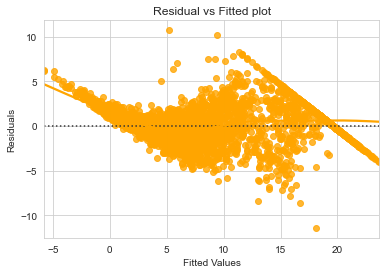

```python
sns.set_style("whitegrid")
sns.residplot(fitted, residual, color="orange", lowess=True)
plt.xlabel("Fitted Values")
plt.ylabel("Residuals")
plt.title("Residual vs Fitted plot")
plt.show()
```

### TEST FOR NORMALITY

**What is the test?**

- Error terms/Residuals should be normally distributed
- If the error terms are non- normally distributed, confidence intervals may become too wide or narrow. Once confidence interval becomes unstable, it leads to difficulty in estimating coefficients based on minimization of least squares.

**What do non-normality indicate?**

- It suggests that there are a few unusual data points which must be studied closely to make a better model.

**How to Check the Normality?**

- It can be checked via QQ Plot, Residuals following normal distribution will make a straight line plot otherwise not.
- Other test to check for normality : Shapiro-Wilk test.

**What is the residuals are not-normal?**

- We can apply transformations like log, exponential, arcsinh, etc. as per our data.

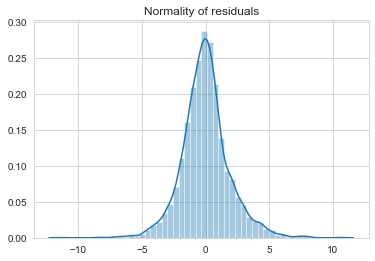

```python
sns.distplot(residual)
plt.title("Normality of residuals")
plt.show()
```

#### The QQ plot of residuals can be used to visually check the normality assumption. The normal probability plot of residuals should approximately follow a straight line.

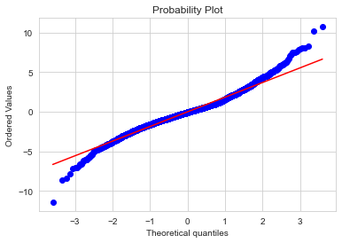

```python
import pylab
import scipy.stats as stats

stats.probplot(residual, dist="norm", plot=pylab)
plt.show()
```

```python
stats.shapiro(residual)
```

```
ShapiroResult(statistic=0.9727505445480347, pvalue=1.2778216809953792e-27)
```

- The residuals are not normal as per shapiro test, but as per QQ plot they are approximately normal.
- The issue with shapiro test is when dataset is big, even for small deviations, it shows data as not normal.
- Hence we go with the QQ plot and say that residuals are normal.

### TEST FOR HOMOSCEDASTICITY

- Test - goldfeldquandt test
- **Homoscedacity**: If the variance of the residuals are symmetrically distributed across the regression line, then the data is said to homoscedastic.
- **Heteroscedacity**: If the variance is unequal for the residuals across the regression line, then the data is said to be heteroscedastic. In this case the residuals can form an arrow shape or any other non symmetrical shape.

For goldfeldquandt test, the null and alternate hypotheses are as follows:

- Null hypothesis : Residuals are homoscedastic
- Alternate hypothesis : Residuals have heteroscedasticity

```python
import statsmodels.stats.api as sms
from statsmodels.compat import lzip

name = ["F statistic", "p-value"]
test = sms.het_goldfeldquandt(residual, X_train6)
lzip(name, test)
```

```
[('F statistic', 1.0629815268633784), ('p-value', 0.0821111767234752)]
```

**Since p-value > 0.05, we can say that residuals are homoscedastic. This assumption is therefore valid in the data.**

### Predicting on the test data

```python
X_train6.columns
```

```
Index(['const', 'Year', 'Mileage', 'Kilometers_Driven_sqrt', 'Power_log',
       'Location_Bangalore', 'Location_Coimbatore', 'Location_Delhi',
       'Location_Hyderabad', 'Location_Kochi', 'Location_Kolkata',
       'Location_Mumbai', 'Location_Pune', 'Fuel_Type_Petrol',
       'Transmission_Manual', 'Owner_Type_Second & Above', 'Brand_Audi',
       'Brand_BMW', 'Brand_Ford', 'Brand_Honda', 'Brand_Hyundai',
       'Brand_Jaguar', 'Brand_Land', 'Brand_Mahindra', 'Brand_Maruti',
       'Brand_Mercedes-Benz', 'Brand_Nissan', 'Brand_Renault', 'Brand_Skoda',
       'Brand_Toyota', 'Brand_Volkswagen'],
      dtype='object')
```

```python
# Selecting columns from test data that we used to create our final model
X_test_final = X_test[X_train6.columns]
```

```python
X_test_final.head()
```

| S.No. | const | Year | Mileage | Kilometers_Driven_sqrt | Power_log | Location_Bangalore | Location_Coimbatore | Location_Delhi | Location_Hyderabad | Location_Kochi | Location_Kolkata | Location_Mumbai | Location_Pune | Fuel_Type_Petrol | Transmission_Manual | Owner_Type_Second & Above | Brand_Audi | Brand_BMW | Brand_Ford | Brand_Honda | Brand_Hyundai | Brand_Jaguar | Brand_Land | Brand_Mahindra | Brand_Maruti | Brand_Mercedes-Benz | Brand_Nissan | Brand_Renault | Brand_Skoda | … |
| --- | --- | --- | --- | --- | --- | --- | --- | --- | --- | --- | --- | --- | --- | --- | --- | --- | --- | --- | --- | --- | --- | --- | --- | --- | --- | --- | --- | --- | --- | --- |
| 2868 | 1.000 | 2013 | 23.400 | 262.679 | 4.304 | 0 | 0 | 0 | 1 | 0 | 0 | 0 | 0 | 0 | 1 | 0 | 0 | 0 | 0 | 0 | 0 | 0 | 0 | 0 | 1 | 0 | 0 | 0 | 0 | … |
| 5924 | 1.000 | 2017 | 15.400 | 163.527 | 4.787 | 0 | 0 | 0 | 0 | 1 | 0 | 0 | 0 | 0 | 1 | 0 | 0 | 0 | 0 | 0 | 0 | 0 | 0 | 1 | 0 | 0 | 0 | 0 | 0 | … |
| 3764 | 1.000 | 2014 | 15.100 | 293.258 | 4.942 | 0 | 0 | 1 | 0 | 0 | 0 | 0 | 0 | 0 | 1 | 0 | 0 | 0 | 0 | 0 | 0 | 0 | 0 | 1 | 0 | 0 | 0 | 0 | 0 | … |
| 4144 | 1.000 | 2016 | 25.000 | 228.035 | 4.234 | 0 | 0 | 0 | 0 | 0 | 0 | 0 | 1 | 0 | 1 | 1 | 0 | 0 | 0 | 0 | 0 | 0 | 0 | 0 | 0 | 0 | 0 | 0 | 0 | … |
| 2780 | 1.000 | 2009 | 18.142 | 316.228 | 4.543 | 0 | 0 | 0 | 0 | 0 | 0 | 0 | 1 | 1 | 1 | 0 | 0 | 0 | 0 | 0 | 1 | 0 | 0 | 0 | 0 | 0 | 0 | 0 | 0 | … |

```python
# Checking model performance on train set
print("Train Performance\n")
model_perf(olsres6, X_train6.values, y_train)
```

```
Train Performance
```

|  | MAE | MAPE | RMSE | R^2 |
| --- | --- | --- | --- | --- |
| 0 | 1.372 | 30.581 | 1.880 | 0.893 |

```python
# Checking model performance on test set
print("Test Performance\n")
model_perf(olsres6, X_test_final.values, y_test)
```

```
Test Performance
```

|  | MAE | MAPE | RMSE | R^2 |
| --- | --- | --- | --- | --- |
| 0 | 1.413 | 32.722 | 1.968 | 0.886 |

##### Observations

- Now we can see that the model has low test and train RMSE and MAE, and both the errors are comparable. So, the model is not suffering from overfitting.
- The model is able to explain 88.6% of the variation on the test set, which is very good.
- The MAPE on the test set suggests we can predict within 32.7% of price.

**Hence, we can conclude *olsres6* is a good predictive model.**

```python
# let us print the model summary

olsmod6 = sm.OLS(y_train, X_train6)
olsres6 = olsmod6.fit()
print(olsres6.summary())
```

```
                            OLS Regression Results
==============================================================================
Dep. Variable:                  Price   R-squared:                       0.893
Model:                            OLS   Adj. R-squared:                  0.892
Method:                 Least Squares   F-statistic:                     1162.
Date:                Tue, 06 Jul 2021   Prob (F-statistic):               0.00
Time:                        14:47:41   Log-Likelihood:                -8638.2
No. Observations:                4213   AIC:                         1.734e+04
Df Residuals:                    4182   BIC:                         1.754e+04
Df Model:                          30
Covariance Type:            nonrobust
=============================================================================================
                                coef    std err          t      P>|t|      [0.025      0.975]
---------------------------------------------------------------------------------------------
const                     -1132.9827     26.144    -43.336      0.000   -1184.239   -1081.727
Year                          0.5589      0.013     42.881      0.000       0.533       0.584
Mileage                      -0.1837      0.012    -15.096      0.000      -0.208      -0.160
Kilometers_Driven_sqrt       -0.0064      0.001    -10.714      0.000      -0.008      -0.005
Power_log                     4.2758      0.144     29.763      0.000       3.994       4.557
Location_Bangalore            0.5528      0.137      4.043      0.000       0.285       0.821
Location_Coimbatore           0.3769      0.117      3.211      0.001       0.147       0.607
Location_Delhi               -0.7121      0.119     -5.991      0.000      -0.945      -0.479
Location_Hyderabad            0.4255      0.108      3.926      0.000       0.213       0.638
Location_Kochi               -0.2945      0.116     -2.531      0.011      -0.523      -0.066
Location_Kolkata             -1.4844      0.123    -12.051      0.000      -1.726      -1.243
Location_Mumbai              -0.5432      0.110     -4.928      0.000      -0.759      -0.327
Location_Pune                -0.2276      0.113     -2.009      0.045      -0.450      -0.005
Fuel_Type_Petrol             -1.9661      0.087    -22.729      0.000      -2.136      -1.796
Transmission_Manual          -1.2723      0.095    -13.337      0.000      -1.459      -1.085
Owner_Type_Second & Above    -0.3004      0.084     -3.588      0.000      -0.464      -0.136
Brand_Audi                    7.7992      0.221     35.339      0.000       7.367       8.232
Brand_BMW                     6.9433      0.218     31.853      0.000       6.516       7.371
Brand_Ford                    1.3207      0.181      7.317      0.000       0.967       1.675
Brand_Honda                   1.0776      0.164      6.562      0.000       0.756       1.400
Brand_Hyundai                 1.3218      0.145      9.090      0.000       1.037       1.607
Brand_Jaguar                  8.0397      0.354     22.717      0.000       7.346       8.734
Brand_Land                    8.5542      0.341     25.101      0.000       7.886       9.222
Brand_Mahindra                0.9945      0.196      5.066      0.000       0.610       1.379
Brand_Maruti                  1.6833      0.144     11.658      0.000       1.400       1.966
Brand_Mercedes-Benz           6.7089      0.211     31.736      0.000       6.294       7.123
Brand_Nissan                  0.6892      0.256      2.691      0.007       0.187       1.191
Brand_Renault                 0.8703      0.232      3.746      0.000       0.415       1.326
Brand_Skoda                   1.6099      0.219      7.352      0.000       1.181       2.039
Brand_Toyota                  4.3684      0.177     24.655      0.000       4.021       4.716
Brand_Volkswagen              0.6157      0.180      3.424      0.001       0.263       0.968
==============================================================================
Omnibus:                      292.511   Durbin-Watson:                   1.953
Prob(Omnibus):                  0.000   Jarque-Bera (JB):             1009.503
Skew:                           0.296   Prob(JB):                    6.16e-220
Kurtosis:                       5.324   Cond. No.                     1.82e+06
==============================================================================

Warnings:
[1] Standard Errors assume that the covariance matrix of the errors is correctly specified.
[2] The condition number is large, 1.82e+06. This might indicate that there are
strong multicollinearity or other numerical problems.
```

# Conclusions

# Insights and Recommendations

Our used car pricing model points to the importance of the following:

- Power: the maximum power of the car engine - the more power, the more costly the car
- Car brand: overall, used cars by luxury brands tend to maintain their high status and be sold at a premium compared to more popular brands
- Location: used car prices are influenced by the location where cars are sold
- Car fuel type: Petrol cars are cheaper than cars run on Diesel
- Mileage: more fuel efficient cars, that run more km on less fuel (higher kmpl), tend to cost less than cars with lower kmpl mileage
- Car transmission: used cars with manual transmission tend to cost less than automatic
- Ownership: used cars previously owned by more than one owner tend to cost less
- Year: not surprisingly though vouched for by the model, newer cars tend to be sold at higher prices
- Kilometers driven: kilometers driven also plays a role in predicting used car prices - the more kilometers driven the cheaper the car tends to be

Every car has a collection of characteristics which make it unique. We only considered a subset of these in our model. Nonetheless, we were able to determine several important predictors that influence used car prices and should be leveraged by Cars4U in its pricing strategy.

Given the model’s predictors we believe that an effective pricing strategy should:

1. Take in consideration several characteristics of a car, namely - as tested by this model - its engine power, brand, transmission type, ownership history, fuel efficiency, make year, and kilometers driven to come up with a price that would be fair and not below market value
1. Be adapted to the car’s location of sale
1. Use the model’s predictors as leverage in developing special sales strategies - especially in market locations in which car prices seem to be inflated or others in which perhaps due to more fierce competition cars seem to be sold below market value - with a clever location buy/sell strategy, for example, Cars4U could leverage such price fluctuations and sell cars at optimum prices